# PSC mice P76_4

Validation of the P76_3 hypotheses

# 1 Introduction

This report tests whether the main transcriptomic findings from the discovery cohort **P76_3** (PSC mouse model, liver RNA-seq, Diet × Sex design) replicate in the independent validation cohort **P76_4**. The hypotheses come from P76_3; this report uses P76_4 only to confirm or reject them.

**Cohort.** P76_4 has 39 animals. One QC outlier (MID 1039) was removed, leaving 38: SD 10F/9M, GFD 10F/9M. Liver tissue was collected on two dates (11_05 and 13_05). The pipeline is the same as for P76_3:

- Salmon/tximport gene counts
- the same gene filter (non-zero count in ≥ 5 samples of at least one group), which kept 23,571 genes
- DESeq2 with the design `~ Date + Diet * Sex`, with SD and female as reference levels
- ashr-shrunken fold changes for gene-level LFC comparisons (H2, H6 sign concordance); unshrunk DESeq2 estimates where the comparison needs them (Wald statistic for GSEA in H4/H5, raw LFCs for the H6 magnitude tests)
- VST expression, with genes z-scored across samples for the panel scores

**Approach.** For each hypothesis, the direction of the effect, the deciding test and its tier were set from the P76_3 results before the P76_4 tests were run:

- **Primary** hypotheses are the confirmatory claims.
- **Secondary** tests are directional supporting evidence.
- **Exploratory** tests follow weaker P76_3 leads.

Panel-level effects come from the model `score ~ Date + Diet * Sex`. Five contrasts are computed from its model-adjusted group means: diet effect in females, diet effect in males, sex effect under SD, sex effect under GFD, and the Diet×Sex interaction. Directional hypotheses are tested one-sided. Claims of “no effect in females” use an equivalence test (TOST, margin ±0.3 z-units), because a non-significant p-value alone cannot show that an effect is absent.

Table 1: Pre-specified hypotheses

| ID | Hypothesis | Tier | Deciding test |
| --- | --- | --- | --- |
| H1 | Sex is the dominant axis of hepatic expression | primary | PERMANOVA: Sex has the largest R² and p < 0.05 |
| H2 | The P76_3 male-diet signature (1286 genes) replicates in P76_4 males | primary | Sign concordance of male LFCs with P76_3 > 50% (binomial, one-sided) |
| H3 | GFD masculinizes the male liver; females are unaffected | primary | masc_index: Diet×Sex interaction > 0 |
| H4 | GFD suppresses lipogenesis/cholesterol synthesis in males only | primary | 3c lipogenesis panel: Diet×Sex interaction < 0 |
| H5 | GFD up-regulates OXPHOS/translation and down-regulates inflammatory programs in males | secondary | Pre-specified GSEA sets, NES in the expected direction (BH over the target sets) |
| H6 | Diet amplifies sexual dimorphism | primary | Absolute sex LFC larger on GFD than on SD across P76_3 sex-DE genes (paired Wilcoxon, one-sided) |
| H7 | Ductular and cholestasis panels respond to diet differently in the two sexes | exploratory | Diet×Sex interaction < 0 |
| H8 | GFD lowers fibrosis markers in males | exploratory | Fibrosis panel: GFD_M − SD_M < 0 |

# 2 Setup

## 2.1 Configuration

All file paths and pre-specified thresholds are defined here.

**Open code**

```r
cohort <- "P76_4"

paths <- list(
  # validation cohort (P76_4)
  txi        = "../Results/transcript_import_P76_4.RData",   # tx2gene + txi
  metadata   = "../../Data/metadata_P076v4.xlsx",
  params     = "../../Data/P076_4_params.xlsx",              # AST, ALT, AlkP2, BiliT
  # discovery cohort (P76_3) result tables written by summarise_res()
  disc_dir      = "../Results",
  # output
  out_dir    = "../Results/validation_P76_4"
)

# QC outlier removed in the P76_4 report (based on the rnaseq_P76_4_part1)
exclude_MID <- c(1039)

# pre-specified thresholds
alpha      <- 0.05   # significance level
lfc_thr    <- 1      # |log2FC| threshold used for "significant genes" (as in P76_3)
eq_margin  <- 0.30   # equivalence margin for panel scores (mean z-score units)
onoff_cut  <- 10      # abs(LFC) in P76_3 above which a gene is treated as on/off
n_perm     <- 9999   # PERMANOVA permutations
set.seed(123)
```

## 2.2 Libraries and helpers

**Open code**

```r
group_colours <- c("GFD_F" = "#e59866",
                   "GFD_M" = "#7fb3d5",
                   "SD_F"  = "#b03a2e",
                   "SD_M"  = "#1c4c78")
```

**Open code**

```r
source("custom_functions_rnaseq.R")
```

## 2.3 Import

**Open code**

```r
# reading metadata
sample_metadata <- read.xlsx(paths$metadata, detectDates = TRUE) %>%
  dplyr::filter(!is.na(SampleID_rna)) %>%
  dplyr::mutate(SampleID = SampleID_rna)

tx2gene <- fread("../../Data/tx2gene.tsv")

# Import Salmon quantifications
files <- read.table("../../Data/samples_P76_4.txt")$V2
files <- paste0("../../", files)
names(files) <- sample_metadata$SampleID

# txi$counts is a gene x sample matrix of estimated counts.
txi <- tximport(
  files,
  type = "salmon",
  tx2gene = tx2gene[, c("tx_id", "gene_id")],
  ignoreTxVersion = TRUE             # handles the ".3" version suffixes
)

save(tx2gene,txi,file="../Results/transcript_import_P76_4.RData")
```

The saved `tximport` object and the P76_4 metadata are loaded. Factors are set with **SD** and **F** as reference levels.

**Open code**

```r
load(paths$txi)   # tx2gene, txi

# reading metadata
sample_metadata <- read.xlsx(paths$metadata, detectDates = TRUE) %>%
  dplyr::filter(!is.na(SampleID_rna)) %>%
  dplyr::mutate(SampleID = SampleID_rna)

# QC exclusion based on part 1
if (length(exclude_MID)) {
  cat("Excluded animals (MID):", paste(exclude_MID, collapse = ", "), "\n")
  sample_metadata <- sample_metadata %>% dplyr::filter(!(MID %in% exclude_MID))
}
```

```
Excluded animals (MID): 1039
```

**Open code**

```r
# creating factors
sample_metadata <- sample_metadata %>%
  dplyr::mutate(
    Diet  = factor(Diet, levels = c("SD", "GFD")),
    Sex   = factor(Sex,  levels = c("F", "M")),
    Group = factor(paste(Diet, Sex, sep = "_"),
                   levels = c("SD_F", "GFD_F", "SD_M", "GFD_M")),
    Date  = factor(gsub("-", "_", Date)),
    Order = as.numeric(Order),
    MID   = as.character(MID)
  )

# align txi columns to metadata rows
all(sample_metadata$SampleID %in% colnames(txi$counts))
```

```
[1] TRUE
```

**Open code**

```r
for (nm in c("abundance", "counts", "length")) {
  txi[[nm]] <- txi[[nm]][, sample_metadata$SampleID, drop = FALSE]
}

# turning the transcript-level annotation table into a gene-level lookup table
# one row per gene, giving its Ensembl ID and its symbol.
sym <- distinct(tx2gene, gene_id, gene_name)

# See the number of samples in each group
table(sample_metadata$Diet, sample_metadata$Sex)
```

```
       F  M
  SD  10  9
  GFD 10  9
```

## 2.4 DESeq2

The design, filter and contrasts are the same as in P76_3.

**Open code**

```r
dds <- DESeqDataSetFromTximport(
  txi,
  colData = sample_metadata,
  design  = as.formula("~ Date + Diet * Sex")
)
```

```
using counts and average transcript lengths from tximport
```

**Open code**

```r
# identical filter to P76_3: non-zero count in >= 5 samples of at least one group
grp  <- sample_metadata$Group
keep <- sapply(levels(grp), function(g) rowSums(counts(dds)[, grp == g, drop = FALSE] > 0) >= 5)
dds  <- dds[rowSums(keep) >= 1, ]
cat(nrow(dds), "genes kept after filtering\n")
```

```
23571 genes kept after filtering
```

**Open code**

```r
dds <- DESeq(dds)
```

```
using 'avgTxLength' from assays(dds), correcting for library size
```

**Open code**

```r
resultsNames(dds)
```

```
[1] "Intercept"           "Date_13_05_vs_11_05" "Diet_GFD_vs_SD"
[4] "Sex_M_vs_F"          "DietGFD.SexM"
```

**Open code**

```r
# Shrinking the lfc
# lfcShrink makes the fold-change estimates more reliable. The raw log2 fold change from DESeq2 is very noisy for genes with few reads or high variability.
res_diet_in_F  <- lfcShrink(dds, coef = "Diet_GFD_vs_SD", type = "ashr")
```

```
using 'ashr' for LFC shrinkage. If used in published research, please cite:
    Stephens, M. (2016) False discovery rates: a new deal. Biostatistics, 18:2.
    https://doi.org/10.1093/biostatistics/kxw041
```

**Open code**

```r
res_diet_in_M  <- lfcShrink(dds, contrast = list(c("Diet_GFD_vs_SD", "DietGFD.SexM")), type = "ashr")
```

```
using 'ashr' for LFC shrinkage. If used in published research, please cite:
    Stephens, M. (2016) False discovery rates: a new deal. Biostatistics, 18:2.
    https://doi.org/10.1093/biostatistics/kxw041
```

**Open code**

```r
res_sex_in_SD  <- lfcShrink(dds, coef = "Sex_M_vs_F", type = "ashr")
```

```
using 'ashr' for LFC shrinkage. If used in published research, please cite:
    Stephens, M. (2016) False discovery rates: a new deal. Biostatistics, 18:2.
    https://doi.org/10.1093/biostatistics/kxw041
```

**Open code**

```r
res_sex_in_GFD <- lfcShrink(dds, contrast = list(c("Sex_M_vs_F", "DietGFD.SexM")), type = "ashr")
```

```
using 'ashr' for LFC shrinkage. If used in published research, please cite:
    Stephens, M. (2016) False discovery rates: a new deal. Biostatistics, 18:2.
    https://doi.org/10.1093/biostatistics/kxw041
```

**Open code**

```r
res_int        <- lfcShrink(dds, coef = "DietGFD.SexM", type = "ashr")
```

```
using 'ashr' for LFC shrinkage. If used in published research, please cite:
    Stephens, M. (2016) False discovery rates: a new deal. Biostatistics, 18:2.
    https://doi.org/10.1093/biostatistics/kxw041
```

**Open code**

```r
# unshrunk Wald statistics - the number DESeq2 uses to compute each gene's p-value.
# It is the log2 fold change divided by its standard error
res_diet_in_M_wald <- results(dds, contrast = list(c("Diet_GFD_vs_SD", "DietGFD.SexM")))
res_int_wald <- results(dds, name = "DietGFD.SexM")

# how many genes in a DESeq2 result table are significant
n_sig <- function(res) sum(!is.na(res$padj) & res$padj < alpha & abs(res$log2FoldChange) >= lfc_thr)

deg_counts <- tibble(
  contrast = c("Diet effect in females", "Diet effect in males",
               "Sex effect in SD", "Sex effect in GFD", "Diet x Sex interaction"),
  P76_3    = c(3, 1286, 564, 6129, 75), # numbers from P76_3
  P76_4    = c(n_sig(res_diet_in_F), n_sig(res_diet_in_M),
               n_sig(res_sex_in_SD), n_sig(res_sex_in_GFD), n_sig(res_int))
)

ktab(deg_counts, "Significant genes (padj < 0.05, |LFC| >= 1): discovery vs validation")
```

Significant genes (padj < 0.05, |LFC| >= 1): discovery vs validation

| contrast | P76_3 | P76_4 |
| --- | --- | --- |
| Diet effect in females | 3 | 0 |
| Diet effect in males | 1286 | 213 |
| Sex effect in SD | 564 | 540 |
| Sex effect in GFD | 6129 | 850 |
| Diet x Sex interaction | 75 | 1 |

## 2.5 Expression matrix and panels

The VST is computed and genes are z-scored across samples, as in P76_3. A panel score is the mean z-score of the panel genes in each sample.

**Open code**

```r
# transforms the counts.The variance-stabilizing transformation converts counts to roughly a log2 scale, where variance is about the same at all expression levels. It also normalizes for sequencing depth.
vsd <- vst(dds, blind = FALSE)
m   <- assay(vsd) # extract the matrix
z   <- t(scale(t(m))) # z-score each gene
cd  <- as.data.frame(colData(dds)) #xtract the sample metadata
```

**Creating the panel of genes**

**Open code**

```r
panels_sym <- list(
  `1a_male_liver`   = c("Hsd3b5","Cyp4a12a","Cyp4a12b","Cyp2d9","Cyp7b1","Slco1a1",
                        "Elovl3","Nudt7","Ugt2b1","Bcl6"),
  `1b_female_liver` = c("Cyp2b9","Cyp3a41a","Cyp3a44","Cyp2a4","Sult3a1","Sult2a1",
                        "Fmo3","A1bg","Nnmt","Cux2"),
  `1c_GH_STAT5`     = c("Ghr","Stat5b","Socs2","Cish","Igf1","Igfals","Socs3"),
  `2_IEG_stress`    = c("Fos","Fosb","Jun","Junb","Jund","Egr1","Atf3","Dusp1",
                        "Nr4a1","Hspa1a","Hspa1b"),
  `3a_GC_targets`   = c("Tsc22d3","Fkbp5","Klf15","Sds","Zbtb16","Per1"),
  `3b_fasting`      = c("Fgf21","Hmgcs2","Cpt1a","Ppargc1a","Pck1","G6pc1",
                        "Angptl4","Slc25a20"),
  `3c_lipogenesis`  = c("Fasn","Scd1","Elovl6","Acaca","Srebf1","Mlxipl","Hmgcs1",
                        "Hmgcr","Sqle","Ldlr","Insig1"),
  `4_circadian`     = c("Arntl","Npas2","Nr1d1","Nr1d2","Per1","Per2","Per3","Cry1",
                        "Cry2","Dbp","Tef","Hlf","Nfil3","Ciart"),
  `5_fibrosis`      = c("Col1a1","Col1a2","Col3a1","Acta2","Timp1","Timp2","Lox",
                        "Pdgfrb","Tgfb1","Sparc"),
  `6_ductular`      = c("Krt19","Krt7","Epcam","Sox9","Spp1","Cldn7","Hnf1b"),
  `7_inflammation`  = c("Ccl2","Ccl5","Cxcl1","Cxcl9","Tnf","Il1b","Il6","Lcn2",
                        "Saa1","Saa2","Adgre1","Itgam","Mmp12"),
  `8_cholestasis`   = c("Cyp7a1","Cyp8b1","Cyp27a1","Cyp2c70","Cyp2a12","Nr0b2",
                        "Nr1h4","Slc10a1","Abcb11","Abcc3","Abcc4","Slc51a","Slc51b",
                        "Baat","Abcb4")
)

# "Mup family "
mup_syms <- grep("^Mup[0-9]", sym$gene_name, value = TRUE) %>% unique()
panels_sym[["1a_male_liver"]] <- c(panels_sym[["1a_male_liver"]], mup_syms)
cat("Mup family notation found in :", length(mup_syms), "genes\n")
```

```
Mup family notation found in : 22 genes
```

**Open code**

```r
# map with gene id and gene name
sym2id <- function(s) sym$gene_id[match(s, sym$gene_name)]

# QC / coverage-check step: for each gene panel
# it counts how many of requested genes actually made it into expression data,
# and reports which genes dropped out and why.
coverage <- lapply(names(panels_sym), function(nm) {
  s  <- panels_sym[[nm]]
  id <- sym2id(s)
  in_annot <- !is.na(id)
  in_data  <- in_annot & id %in% rownames(m)
  data.frame(
    panel             = nm,
    requested         = length(s),
    in_data           = sum(in_data),
    not_in_annotation = paste(s[!in_annot],            collapse = ", "),
    filtered_lowcount = paste(s[in_annot & !in_data],  collapse = ", ")
  )
}) %>% dplyr::bind_rows()

# case-insensitive
missing_all <- unique(unlist(lapply(panels_sym, function(s) s[is.na(sym2id(s))])))
if (length(missing_all)) {
  cat("\ncase-insensitive:\n")
  for (g in missing_all) {
    hit <- grep(paste0("^", g, "$"), sym$gene_name, ignore.case = TRUE, value = TRUE)
    if (length(hit)) cat(sprintf("  %-12s -> %s\n", g, paste(hit, collapse = ", ")))
  }
}
```

```
case-insensitive:
```

**Open code**

```r
# final panels
panels <- lapply(panels_sym, function(s) {
  id <- sym2id(s); unique(id[!is.na(id) & id %in% rownames(m)])
})

ktab(coverage, "Genes detected in our RNAseq dataset")
```

Genes detected in our RNAseq dataset

| panel | requested | in_data | not_in_annotation | filtered_lowcount |
| --- | --- | --- | --- | --- |
| 1a_male_liver | 32 | 31 |  | Mup4 |
| 1b_female_liver | 10 | 10 |  |  |
| 1c_GH_STAT5 | 7 | 7 |  |  |
| 2_IEG_stress | 11 | 11 |  |  |
| 3a_GC_targets | 6 | 6 |  |  |
| 3b_fasting | 8 | 8 |  |  |
| 3c_lipogenesis | 11 | 11 |  |  |
| 4_circadian | 14 | 13 | Arntl |  |
| 5_fibrosis | 10 | 10 |  |  |
| 6_ductular | 7 | 7 |  |  |
| 7_inflammation | 13 | 13 |  |  |
| 8_cholestasis | 15 | 15 |  |  |

**Open code**

```r
score_panels <- function(panels, zmat) {
  sc <- sapply(panels, function(ids) colMeans(zmat[ids, , drop = FALSE], na.rm = TRUE))
  cbind(sc, masc_index = sc[, "1a_male_liver"] - sc[, "1b_female_liver"])
}
scores      <- score_panels(panels, z)   # primary
identical(rownames(scores), rownames(cd))
```

```
[1] TRUE
```

The panel models are `score ~ Date + Diet * Sex`. From the model-adjusted means of the four cells (`emmeans`), five pre-defined contrasts are computed:

- `diet_in_F` = GFD_F − SD_F
- `diet_in_M` = GFD_M − SD_M
- `sex_in_SD` = SD_M − SD_F
- `sex_in_GFD` = GFD_M − GFD_F
- `interaction` = (GFD_M − SD_M) − (GFD_F − SD_F), identical to the DietGFD:SexM coefficient

**Open code**

```r
results_log <- list()
cell_contrasts <- list(
  diet_in_F   = c(-1,  1,  0, 0),
  diet_in_M   = c( 0,  0, -1, 1),
  sex_in_SD   = c(-1,  0,  1, 0),
  sex_in_GFD  = c( 0, -1,  0, 1),
  interaction = c( 1, -1, -1, 1)
)

score_contrasts <- function(y, cd, name, extra = "") {
  f   <- as.formula(paste("y ~ Date + ", extra, "Diet * Sex"))
  fit <- lm(f, data = cbind(cd, y = y))
  emm <- emmeans(fit, ~ Diet * Sex)
  grid <- as.data.frame(emm)
  stopifnot(identical(paste(grid$Diet, grid$Sex), c("SD F", "GFD F", "SD M", "GFD M")))
  out <- as.data.frame(contrast(emm, method = cell_contrasts, adjust = "none"))
  out$panel <- name
  out %>% dplyr::select(panel, contrast, estimate, SE, df, t.ratio, p.value)
}

all_panel_contrasts <- function(sc, cd, extra = "") {
  bind_rows(lapply(colnames(sc), function(nm) score_contrasts(sc[, nm], cd, nm, extra)))
}

# runs the model for every panel, using the panel scores built with the P76_3 gene mapping (the primary analysis).
pc      <- all_panel_contrasts(scores, cd)

# small lookup helper. It returns the row of a contrast table for one panel and one contrast
get_c <- function(tab, panel, contrast) tab[tab$panel == panel & tab$contrast == contrast, ]

# P76_3 reference values
# note negative interaction effect means the the effect is more negative in males than in females, positive int. means the effect is more positive in males than in females
disc_ref <- tribble(
  ~panel,            ~contrast,     ~P76_3,
  "1a_male_liver",   "interaction",  0.549,
  "1a_male_liver",   "diet_in_M",    0.590,
  "masc_index",      "interaction",  0.399,
  "masc_index",      "diet_in_M",    0.426,
  "1b_female_liver", "interaction",  0.151,
  "3c_lipogenesis",  "interaction", -1.0625,
  "3c_lipogenesis",  "diet_in_M",   -1.123,
  "2_IEG_stress",    "diet_in_M",   -0.7225,
  "4_circadian",     "interaction", -0.5417,
  "5_fibrosis",      "sex_in_SD",   -0.5109,
  "5_fibrosis",      "diet_in_M",   -0.7565,
  "6_ductular",      "interaction", -0.6591,
  "8_cholestasis",   "interaction", -0.1323
)
```

**Open code**

```r
plot_panels <- function(sc, panel_names, title) {
  sc <- as.data.frame(sc[, panel_names, drop = FALSE])
  sc_long <- sc %>%
  dplyr::mutate(Group = cd$Group, Diet = cd$Diet, Sex = cd$Sex) %>%
  tidyr::pivot_longer(dplyr::all_of(colnames(sc)),
                      names_to = "panel", values_to = "score") %>%
  dplyr::mutate(panel = factor(panel, levels = colnames(sc)))

pvals <- sc_long %>%
  group_by(panel, Sex) %>%
  summarise(p = wilcox.test(score ~ Diet)$p.value,
            top = max(score, na.rm = TRUE),
            rng = diff(range(score, na.rm = TRUE)),
            .groups = "drop") %>%
  mutate(y = top - 0 * rng,
         label = ifelse(p < 0.001, "***",
                 ifelse(p < 0.01,  "**",
                 ifelse(p < 0.05,  "*", "ns"))))


  sc %>%
    rownames_to_column("SampleID") %>%
    left_join(cd %>% dplyr::select(SampleID, Diet, Sex, Group),
              by = "SampleID") %>%
    pivot_longer(all_of(panel_names), names_to = "panel", values_to = "score") %>%
    dplyr::mutate(panel = factor(panel, levels = panel_names)) %>%
    ggplot(aes(Diet, score, fill = Group)) +
    geom_boxplot(outlier.shape = NA, alpha = 0.85) +
    geom_jitter(width = 0.15, size = 1, alpha = 0.6) +
        geom_text(data = pvals, aes(x = 1.5, y = y, label = label),
            inherit.aes = FALSE, size = 4) +
    facet_grid(panel ~ Sex, scales = "free_y", switch = "y") +
    scale_fill_manual(values = group_colours) +
    labs(y = "Score (mean z-score of panel)", x = NULL, title = title) +
    theme_bw()
}
```

# 3 Cohort description

**Open code**

```r
ktab(as.data.frame.matrix(table(cd$Diet, cd$Sex)) %>% rownames_to_column("Diet"),
     "Animals per Diet × Sex cell")
```

Animals per Diet × Sex cell

| Diet | F | M |
| --- | --- | --- |
| SD | 10 | 9 |
| GFD | 10 | 9 |

# 4 H1: Sex is the dominant axis

**Hypothesis.** Sex explains more variance in hepatic expression than Diet or Diet×Sex.

**Test.** PERMANOVA on Euclidean distances of the 2,000 most variable VST genes, `~ Diet * Sex` with permutations stratified by collection date (`strata = Date`), sequential terms.

Replication means that Sex has the largest R² of all terms *and* p < α.

**P76_3.** Sex R² = 0.3149, p = 1e-4 (Diet 0.0595, Diet×Sex 0.05538).

**Open code**

```r
rv   <- rowVars(m)
top  <- order(rv, decreasing = TRUE)[seq_len(min(2000, length(rv)))]
mat  <- t(m[top, ])
meta <- cd[rownames(mat), ]
d    <- dist(mat)

bd <- betadisper(d, meta$Group)
ktab(as.data.frame(anova(bd)), "Dispersion homogeneity (betadisper)")
```

Dispersion homogeneity (betadisper)

|  | Df | Sum Sq | Mean Sq | F value | Pr(>F) |
| --- | --- | --- | --- | --- | --- |
| Groups | 3 | 1010 | 336.7 | 1.24 | 0.3103 |
| Residuals | 34 | 9228 | 271.4 | NA | NA |

**Open code**

```r
pmv <- adonis2(as.formula("d ~ Diet * Sex"),
               data = meta,
               by = "terms",
               permutations = n_perm,
               strata=meta$Date)

ktab(as.data.frame(pmv), "PERMANOVA (strata=Date): Diet * Sex")
```

PERMANOVA (strata=Date): Diet * Sex

|  | Df | SumOfSqs | R2 | F | Pr(>F) |
| --- | --- | --- | --- | --- | --- |
| Diet | 1 | 3668 | 0.03375 | 1.793 | 0.1121 |
| Sex | 1 | 31270 | 0.28770 | 15.290 | 0.0001 |
| Diet:Sex | 1 | 4193 | 0.03858 | 2.050 | 0.0774 |
| Residual | 34 | 69550 | 0.63990 | NA | NA |
| Total | 37 | 108700 | 1.00000 | NA | NA |

**Open code**

```r
terms_r2  <- pmv$R2[!rownames(pmv) %in% c("Residual", "Total")]
names(terms_r2) <- rownames(pmv)[!rownames(pmv) %in% c("Residual", "Total")]
sex_top   <- names(which.max(terms_r2)) == "Sex"

log_result("H1", "primary",
           "Sex = dominant axis (PERMANOVA Sex R²)", "adonis2, Sex term",
           "-", "-",
           estimate = pmv["Sex", "R2"],
           p = pmv["Sex", "Pr(>F)"],
           disc = 0.3149,
           note = paste("Sex has largest R²:", sex_top))

log_result("H2", "secondary",
           "Diet×Sex interaction on global profile (PERMANOVA R²)",
           "adonis2, Diet:Sex term",
           "-", "-",
           estimate = pmv["Diet:Sex", "R2"],
           p = pmv["Diet:Sex", "Pr(>F)"],
           disc = 0.0554)
```

**Open code**

```r
bind_rows(results_log) %>%
  dplyr::filter(id == "H1") %>%
  ktab("H1: hypothesis test Sex = dominant axis (PERMANOVA Sex R²)")
```

H1: hypothesis test Sex = dominant axis (PERMANOVA Sex R²)

| id | tier | what | test | type | expected | P76_3 | P76_4 | p | note |
| --- | --- | --- | --- | --- | --- | --- | --- | --- | --- |
| H1 | primary | Sex = dominant axis (PERMANOVA Sex R²) | adonis2, Sex term | - | - | 0.3149 | 0.2877 | 1e-04 | Sex has largest R²: TRUE |

## 4.1 Visualization

**Open code**

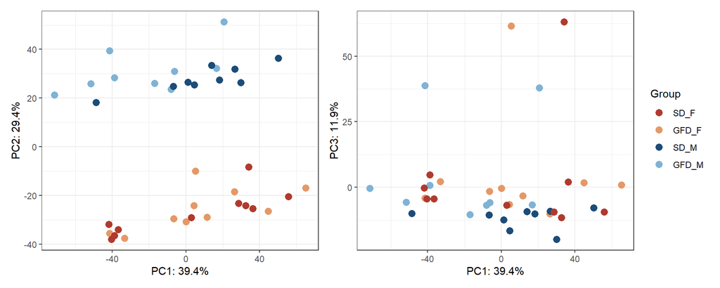

```r
pca <- prcomp(mat)
pv  <- round(100 * pca$sdev^2 / sum(pca$sdev^2), 1)
pca_df <- as.data.frame(pca$x[, 1:3]) %>% bind_cols(meta[, c("Group", "Sex", "Diet", "Date")])

p12 <- ggplot(pca_df, aes(PC1, PC2, colour = Group)) +
  geom_point(size = 3) + scale_colour_manual(values = group_colours) +
  labs(x = paste0("PC1: ", pv[1], "%"), y = paste0("PC2: ", pv[2], "%")) +
  theme_bw()

p13 <- ggplot(pca_df, aes(PC1, PC3, colour = Group)) +
  geom_point(size = 3) + scale_colour_manual(values = group_colours) +
  labs(x = paste0("PC1: ", pv[1], "%"), y = paste0("PC3: ", pv[3], "%")) +
  theme_bw()

p12 + p13 + plot_layout(guides = "collect")
```

# 5 H2: Replication of the male diet signature

**Hypothesis.** The P76_3 male-diet signature (1286 genes, padj < 0.05, |LFC| ≥ 1) reproduces in P76_4 males.

**Tests.**

- *Primary:* the GFD-vs-SD log2FC in P76_4 males agrees in sign with P76_3 for more than 50% of the genes (binomial, one-sided).
- *Secondary:* the P76_3 and P76_4 male LFCs correlate positively (Spearman, one-sided, rho > 0).
- *Secondary:* Diet×Sex term of the global PERMANOVA (section H1), p < 0.05.

**Open code**

```r
disc_M <- read.xlsx(file.path(paths$disc_dir, "Diet effect in males.xlsx"))
cat("P76_3 male-diet genes:", nrow(disc_M), "\n")
```

```
P76_3 male-diet genes: 1286
```

**Open code**

```r
# builds a comparison table with one row per P76_3 male-diet gene.
cmp <- disc_M %>%
  dplyr::select(gene_id, gene_name, lfc_disc = log2FoldChange) %>%
  inner_join(res_to_df(res_diet_in_M) %>%
               dplyr::select(gene_id, lfc_M = log2FoldChange, padj_M = padj),
             by = "gene_id") %>%
  inner_join(res_to_df(res_diet_in_F) %>%
               dplyr::select(gene_id, lfc_F = log2FoldChange),
             by = "gene_id") %>%
  dplyr::mutate(onoff = abs(lfc_disc) >= onoff_cut)

cat("Found in P76_4 after filtering:", nrow(cmp), "of", nrow(disc_M), "\n")
```

```
Found in P76_4 after filtering: 1276 of 1286
```

**Open code**

```r
head(cmp)
```

```
             gene_id gene_name  lfc_disc      lfc_M     padj_M         lfc_F
1 ENSMUSG00000000031       H19 -2.946449 -0.4385399 0.19741465  4.428677e-03
2 ENSMUSG00000000296   Tpd52l1  1.033980  0.7367312 0.01325574  4.783394e-03
3 ENSMUSG00000000555     Itga5 -1.072181 -0.6697499 0.04052565 -2.437571e-03
4 ENSMUSG00000000827   Tpd52l2  1.047075  0.5370533 0.07650817 -3.426782e-03
5 ENSMUSG00000000957     Mmp14 -1.020800 -0.8598057 0.01022661 -2.052400e-04
6 ENSMUSG00000001105     Ift20  1.171264  0.7601687 0.01629965  2.474448e-05
  onoff
1 FALSE
2 FALSE
3 FALSE
4 FALSE
5 FALSE
6 FALSE
```

**Open code**

```r
signature_tests <- function(df, label) {
  s   <- sign(df$lfc_disc) # direction

  # the number of genes whose P76_4 male LFC points the same way as in P76_3 males. Male
  # vs male: "does the male effect replicate?"
  kM  <- sum(sign(df$lfc_M) == s)

  n <- nrow(df)

  # could this many genes agree with P76_3 just by luck?
  bM  <- binom.test(kM, n, 0.5, alternative = "greater")

  # correlation
  ct  <- suppressWarnings(
    cor.test(df$lfc_disc,
             df$lfc_M,
             method = "spearman",
             alternative = "greater"))

  tibble(set = label, # Which genes were used
         n_genes = n, # Number of P76_3 genes also found in P76_4
         concord_M = kM / n, # Fraction of genes whose P76_4 male LFC has the same sign as in P76_3
         p_concord_M = bM$p.value, # One-sided binomial test that concord_M > 0.5
         rho_M = unname(ct$estimate), # Spearman correlation between P76_3 LFC and P76_4 male LFC
         p_rho_M = ct$p.value) #    One-sided test that rho_M > 0
}

h2_tab <- signature_tests(
  cmp, "all P76_3 male-diet genes")

ktab(h2_tab, "H2: gene-level replication of the P76_3 male-diet signature")
```

H2: gene-level replication of the P76_3 male-diet signature

| set | n_genes | concord_M | p_concord_M | rho_M | p_rho_M |
| --- | --- | --- | --- | --- | --- |
| all P76_3 male-diet genes | 1276 | 0.9647 | 0 | 0.7754 | 0 |

**Open code**

```r
log_result("H2",
           "primary",
           "Sign concordance of male diet LFC",
           "binomial, one-sided",
           "dir", ">0.5",
           estimate = h2_tab$concord_M[1],
           p = h2_tab$p_concord_M[1])

log_result("H2",
           "secondary",
           "LFC correlation P76_3 vs P76_4 (males)",
           "Spearman, one-sided",
           "dir", ">0",
           estimate = h2_tab$rho_M[1], p = h2_tab$p_rho_M[1])
```

**Open code**

```r
bind_rows(results_log) %>%
  dplyr::filter(id == "H2") %>%
  ktab("H2: Replication of the P76_3 male diet signature")
```

H2: Replication of the P76_3 male diet signature

| id | tier | what | test | type | expected | P76_3 | P76_4 | p | note |
| --- | --- | --- | --- | --- | --- | --- | --- | --- | --- |
| H2 | secondary | Diet×Sex interaction on global profile (PERMANOVA R²) | adonis2, Diet:Sex term | - | - | 0.0554 | 0.03858 | 0.0774 |  |
| H2 | primary | Sign concordance of male diet LFC | binomial, one-sided | dir | >0.5 | NA | 0.96470 | 0.0000 |  |
| H2 | secondary | LFC correlation P76_3 vs P76_4 (males) | Spearman, one-sided | dir | >0 | NA | 0.77540 | 0.0000 |  |

## 5.1 Visualization

**Open code**

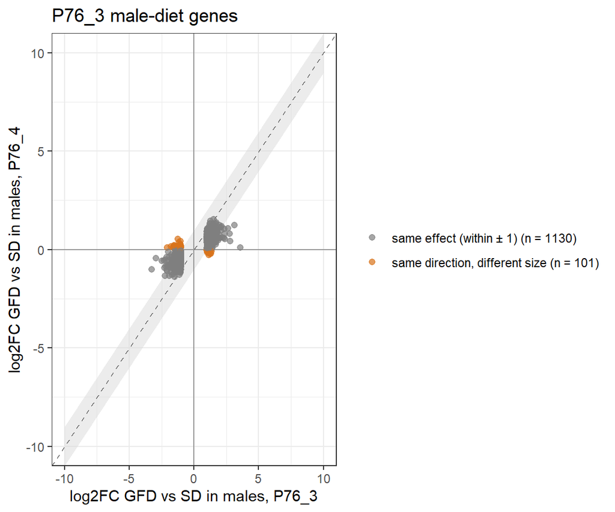

```r
tol <- 1

cmp_plot <- cmp %>%
  dplyr::mutate(
    agreement = dplyr::case_when(
      abs(lfc_M - lfc_disc) <= tol          ~ "same effect (within ± 1)",
      sign(lfc_M) == sign(lfc_disc)         ~ "same direction, different size",
      TRUE                                  ~ "opposite direction"
    ),
    agreement = factor(agreement, levels = c("same effect (within ± 1)",
                                             "same direction, different size",
                                             "opposite direction"))
  )

# counts in the legend
n_tab  <- table(cmp_plot$agreement)
labs_n <- paste0(names(n_tab), " (n = ", n_tab, ")")

ggplot(cmp_plot, aes(lfc_disc, lfc_M)) +
  # shaded "same effect" band around y = x
  annotate("polygon",
           x = c(-10, 10, 10, -10),
           y = c(-10 - tol, 10 - tol, 10 + tol, -10 + tol),
           fill = "grey85", alpha = 0.5) +
  geom_hline(yintercept = 0, colour = "grey60") +
  geom_vline(xintercept = 0, colour = "grey60") +
  geom_abline(slope = 1, intercept = 0, linetype = "dashed", colour = "grey40") +
  geom_point(aes(colour = agreement), alpha = 0.7, size = 1.8) +
  scale_colour_manual(values = c("same effect (within ±tol)"      = "#1f6fb2",
                                 "same direction, different size" = "grey50",
                                 "opposite direction"             = "#d9731a"),
                      labels = labs_n, name = NULL, drop = FALSE) +
  labs(x = "log2FC GFD vs SD in males, P76_3",
       y = "log2FC GFD vs SD in males, P76_4",
       title = "P76_3 male-diet genes") +
  theme_bw() +
  theme(legend.position = "right") +
  coord_cartesian(xlim = c(-10, 10), ylim = c(-10, 10))
```

**Open code**

```r
# ---- settings ----
xlim_val <- 4
ylim_val <- 2
# tol is assumed to be defined already (e.g. tol <- 1)

# ---- categories and statistics ----
lvls <- c("same effect (within ± 1)",
          "same direction, different size",
          "opposite direction")

cmp_plot <- cmp_plot %>%
  mutate(agreement = factor(agreement, levels = lvls))

n_genes <- nrow(cmp_plot)
pct     <- round(100 * prop.table(table(cmp_plot$agreement)))
rho     <- cor(cmp_plot$lfc_disc, cmp_plot$lfc_M, method = "spearman")

agr_labels <- c(
  "same effect (within ± 1)"      = paste0("same direction, |Δlog2FC| ≤ ", tol, " (", pct[1], " %)"),
  "same direction, different size" = paste0("same direction, |Δlog2FC| > ", tol, " (", pct[2], " %)"),
  "opposite direction"             = paste0("opposite direction (", pct[3], " %)")
)

stat_label <- paste0("\u03C1 = ", sprintf("%.2f", rho), ", ",
                     format(n_genes, big.mark = " "), " genes")

# how many points fall outside the displayed range
sum(abs(cmp_plot$lfc_disc) > xlim_val)
```

```
[1] 0
```

**Open code**

```r
sum(abs(cmp_plot$lfc_M)    > ylim_val)
```

```
[1] 0
```

**Open code**

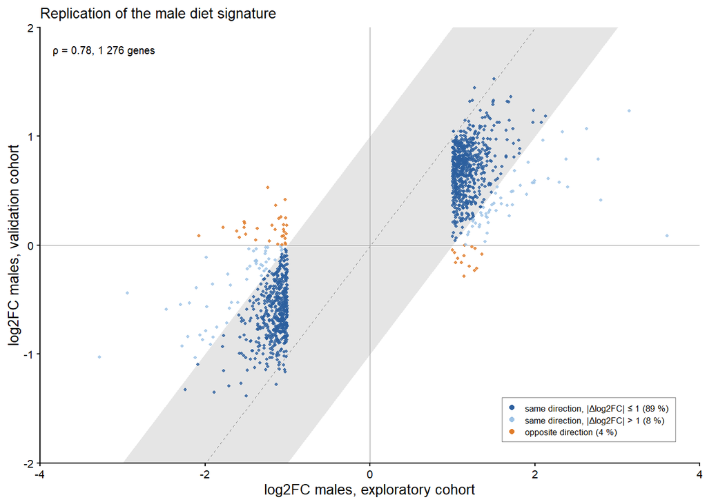

```r
# ---- plot ----
f_5f <- ggplot(cmp_plot, aes(lfc_disc, lfc_M)) +
  # ±tol band around y = x
  annotate("polygon",
           x = c(-xlim_val, xlim_val, xlim_val, -xlim_val),
           y = c(-xlim_val - tol, xlim_val - tol, xlim_val + tol, -xlim_val + tol),
           fill = "grey90") +
  geom_hline(yintercept = 0, colour = "grey60", linewidth = 0.3) +
  geom_vline(xintercept = 0, colour = "grey60", linewidth = 0.3) +
  geom_abline(slope = 1, intercept = 0, linetype = "dashed",
              colour = "grey50", linewidth = 0.3) +
  geom_point(aes(colour = agreement), size = 0.7, alpha = 0.8) +
  scale_colour_manual(values = c("same effect (within ± 1)"      = "#2C5F9E",
                                 "same direction, different size" = "#9DC3E6",
                                 "opposite direction"             = "#E07B28"),
                      labels = agr_labels, name = NULL, drop = FALSE) +
  annotate("text", x = -xlim_val + 0.15, y = ylim_val * 0.9, label = stat_label,
           hjust = 0, size = 2.6) +
  guides(colour = guide_legend(override.aes = list(size = 1.5, alpha = 1))) +
  coord_cartesian(xlim = c(-xlim_val, xlim_val),
                  ylim = c(-ylim_val, ylim_val), expand = FALSE) +
  labs(x = "log2FC males, exploratory cohort", y = "log2FC males, validation cohort",
       title = "Replication of the male diet signature") +
  theme_classic(base_size = 10) +
  theme(
    legend.position      = c(0.70, 0.15),
    legend.justification   = c(0, 1),
    legend.text            = element_text(size = 6.5),
    legend.key.size        = unit(0.3, "cm"),
    legend.background      = element_rect(fill = "white", colour = "grey50", linewidth = 0.3),
    legend.margin          = margin(3, 5, 3, 3),
    plot.title             = element_text(size = 10, face = "plain"),
    plot.tag               = element_text(size = 14, face = "bold"),
    axis.text              = element_text(colour = "black", size = 8),
    axis.line              = element_line(linewidth = 0.4),
    axis.ticks             = element_line(linewidth = 0.4)
  )

f_5f
```

**Open code**

```r
save(f_5f,file = "../Results/figures/F5F.RData")
```

# 6 H3: GFD hyper-masculinizes the male liver

**Hypothesis.** Under GFD, the male-liver program (1a) and the masculinization index increase in males only.

**Tests.**

- *Primary:* masc_index interaction > 0 (one-sided).
- *Secondary:* 1a panel interaction > 0 (one-sided).
- *Secondary:* GFD_M − SD_M (Diet in M) > 0 for both scores.
- *Secondary:* female diet effect equivalent to 0 (TOST, ± `eq_margin`).

**P76_3.**

- 1a interaction +0.549 (padj 0.0006)
- masc_index interaction +0.399 (padj 0.008)
- no female effect (0.0407; padj 0.670)

**Open code**

```r
# Male liver panel
h3 <- pc %>%
  dplyr::filter(
    panel %in% c("1a_male_liver", "1b_female_liver", "1c_GH_STAT5", "masc_index")) %>%
  left_join(disc_ref, by = c("panel", "contrast"))

ktab(h3, "H3: sex-program panel contrasts (P76_3 panel mapping)")
```

H3: sex-program panel contrasts (P76_3 panel mapping)

| panel | contrast | estimate | SE | df | t.ratio | p.value | P76_3 |
| --- | --- | --- | --- | --- | --- | --- | --- |
| 1a_male_liver | diet_in_F | -0.071250 | 0.1690 | 33 | -0.42160 | 0.676100 | NA |
| 1a_male_liver | diet_in_M | 0.451300 | 0.1803 | 33 | 2.50300 | 0.017420 | 0.590 |
| 1a_male_liver | sex_in_SD | 1.328000 | 0.1738 | 33 | 7.64200 | 0.000000 | NA |
| 1a_male_liver | sex_in_GFD | 1.851000 | 0.1749 | 33 | 10.58000 | 0.000000 | NA |
| 1a_male_liver | interaction | 0.522600 | 0.2471 | 33 | 2.11500 | 0.042090 | 0.549 |
| 1b_female_liver | diet_in_F | -0.124500 | 0.1374 | 33 | -0.90600 | 0.371500 | NA |
| 1b_female_liver | diet_in_M | 0.036680 | 0.1466 | 33 | 0.25030 | 0.803900 | NA |
| 1b_female_liver | sex_in_SD | -1.751000 | 0.1413 | 33 | -12.40000 | 0.000000 | NA |
| 1b_female_liver | sex_in_GFD | -1.590000 | 0.1422 | 33 | -11.19000 | 0.000000 | NA |
| 1b_female_liver | interaction | 0.161200 | 0.2009 | 33 | 0.80230 | 0.428100 | 0.151 |
| 1c_GH_STAT5 | diet_in_F | 0.007089 | 0.1887 | 33 | 0.03756 | 0.970300 | NA |
| 1c_GH_STAT5 | diet_in_M | -0.420500 | 0.2013 | 33 | -2.08900 | 0.044530 | NA |
| 1c_GH_STAT5 | sex_in_SD | 0.130600 | 0.1940 | 33 | 0.67290 | 0.505700 | NA |
| 1c_GH_STAT5 | sex_in_GFD | -0.297000 | 0.1953 | 33 | -1.52100 | 0.137800 | NA |
| 1c_GH_STAT5 | interaction | -0.427600 | 0.2759 | 33 | -1.54900 | 0.130800 | NA |
| masc_index | diet_in_F | 0.053240 | 0.1232 | 33 | 0.43230 | 0.668400 | NA |
| masc_index | diet_in_M | 0.414600 | 0.1314 | 33 | 3.15600 | 0.003405 | 0.426 |
| masc_index | sex_in_SD | 3.079000 | 0.1266 | 33 | 24.32000 | 0.000000 | NA |
| masc_index | sex_in_GFD | 3.441000 | 0.1274 | 33 | 27.00000 | 0.000000 | NA |
| masc_index | interaction | 0.361400 | 0.1801 | 33 | 2.00700 | 0.053020 | 0.399 |

**Open code**

```r
r <- get_c(pc, "1a_male_liver", "interaction")

log_result("H3", "secondary",
           "1a male-liver: Diet×Sex interaction",
           "lm + emmeans, one-sided",
           "dir", ">0",
           estimate = r$estimate,
           p = p_dir(r$t.ratio, r$df, +1),
           disc =  disc_ref$P76_3[(disc_ref$panel == "1a_male_liver") & disc_ref$contrast == "interaction"])

# Masc index
r <- get_c(pc, "masc_index", "interaction")

log_result("H3", "primary",
           "masc_index: Diet×Sex interaction",
           "lm + emmeans, one-sided",
           "dir", ">0",
           estimate = r$estimate,
           p = p_dir(r$t.ratio, r$df, +1),
           disc = disc_ref$P76_3[(disc_ref$panel == "masc_index") & disc_ref$contrast == "interaction"])

for (pn in c("1a_male_liver", "masc_index")) {
  r <- get_c(pc, pn, "diet_in_M")
  log_result("H3", "secondary",
             paste0(pn, ": GFD_M − SD_M"),
             "lm + emmeans, one-sided",
             "dir", ">0",
             estimate = r$estimate,
             p = p_dir(r$t.ratio, r$df, +1),
             disc = disc_ref$P76_3[(disc_ref$panel == pn) & disc_ref$contrast == "diet_in_M"])

  r <- get_c(pc, pn, "diet_in_F")
  log_result("H3", "secondary",
             paste0(pn, ": no diet effect in females"),
             paste0("TOST ±", eq_margin), "tost", "≈0",
             estimate = r$estimate,
             # calculate TOST based on estimate, SE and df +- eq_margin
             p = p_tost(r$estimate, r$SE, r$df, eq_margin))
}
```

**Open code**

```r
bind_rows(results_log) %>%
  dplyr::filter(id == "H3") %>%
  ktab("H3: GFD hyper-masculinizes the male liver")
```

H3: GFD hyper-masculinizes the male liver

| id | tier | what | test | type | expected | P76_3 | P76_4 | p | note |
| --- | --- | --- | --- | --- | --- | --- | --- | --- | --- |
| H3 | secondary | 1a male-liver: Diet×Sex interaction | lm + emmeans, one-sided | dir | >0 | 0.549 | 0.52260 | 0.021050 |  |
| H3 | primary | masc_index: Diet×Sex interaction | lm + emmeans, one-sided | dir | >0 | 0.399 | 0.36140 | 0.026510 |  |
| H3 | secondary | 1a_male_liver: GFD_M − SD_M | lm + emmeans, one-sided | dir | >0 | 0.590 | 0.45130 | 0.008712 |  |
| H3 | secondary | 1a_male_liver: no diet effect in females | TOST ±0.3 | tost | ≈0 | NA | -0.07125 | 0.092540 |  |
| H3 | secondary | masc_index: GFD_M − SD_M | lm + emmeans, one-sided | dir | >0 | 0.426 | 0.41460 | 0.001703 |  |
| H3 | secondary | masc_index: no diet effect in females | TOST ±0.3 | tost | ≈0 | NA | 0.05324 | 0.026690 |  |

## 6.1 Visualization

**Open code**

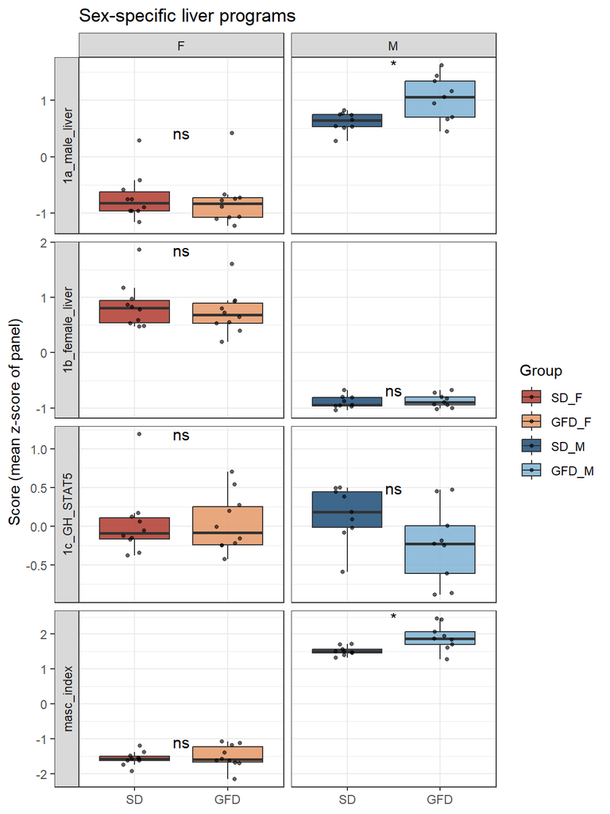

```r
plot_panels(scores,
            c("1a_male_liver", "1b_female_liver", "1c_GH_STAT5", "masc_index"),
            "Sex-specific liver programs")
```

**Open code**

```r
sc <- scores
panel_names <- c("1a_male_liver", "1b_female_liver", "1c_GH_STAT5", "masc_index")

sc <- as.data.frame(sc[, panel_names, drop = FALSE])

sc_long <- sc %>%
  dplyr::mutate(Group = cd$Group, Diet = cd$Diet, Sex = cd$Sex) %>%
  tidyr::pivot_longer(dplyr::all_of(colnames(sc)),
                      names_to = "panel", values_to = "score") %>%
  dplyr::mutate(panel = factor(panel, levels = colnames(sc)))

pvals <- sc_long %>%
  group_by(panel, Sex) %>%
  summarise(p = wilcox.test(score ~ Diet)$p.value,
            top = max(score, na.rm = TRUE),
            rng = diff(range(score, na.rm = TRUE)),
            .groups = "drop") %>%
  mutate(y = top - 0 * rng,
         label = ifelse(p < 0.001, "***",
                 ifelse(p < 0.01,  "**",
                 ifelse(p < 0.05,  "*", "ns"))))

save(sc_long,pvals,file="../Results/figures/F5C_data_validation.RData")
```

# 7 H4: GFD suppresses lipogenesis/cholesterol-synthesis in males

**Hypothesis.** The lipogenesis/cholesterol-synthesis program (3c) falls under GFD in males only.

**Tests.**

- *Primary:* 3c interaction < 0 (one-sided).
- *Secondary:* GFD_M − SD_M < 0 (one-sided).
- *Secondary:* female diet effect equivalent to 0 (TOST, ± `eq_margin`).
- *Secondary:* cholesterol-homeostasis and SREBP gene sets are negatively enriched in the male diet ranking (tested together with H5 in the GSEA section below).

**P76_3.**

- 3c interaction −1.0625 (padj 0.00928)
- GFD_M − SD_M = −1.123
- HALLMARK_CHOLESTEROL_HOMEOSTASIS NES = −2.78
- REACTOME_ACTIVATION_OF_GENE_EXPRESSION_BY_SREBF_SREBP NES = −2.60
- REACTOME_REGULATION_OF_CHOLESTEROL_BIOSYNTHESIS_BY_SREBP_SREBF NES = −2.65

**Open code**

```r
h4 <- pc %>%
  dplyr::filter(panel %in% c("2_IEG_stress",
                             "3a_GC_targets",
                             "3b_fasting", "3c_lipogenesis")) %>%
  left_join(disc_ref, by = c("panel", "contrast"))

ktab(h4, "H4: metabolic panel contrasts (P76_3 panel mapping)")
```

H4: metabolic panel contrasts (P76_3 panel mapping)

| panel | contrast | estimate | SE | df | t.ratio | p.value | P76_3 |
| --- | --- | --- | --- | --- | --- | --- | --- |
| 2_IEG_stress | diet_in_F | 0.006905 | 0.2894 | 33 | 0.02386 | 0.9811000 | NA |
| 2_IEG_stress | diet_in_M | -0.744500 | 0.3087 | 33 | -2.41100 | 0.0216100 | -0.7225 |
| 2_IEG_stress | sex_in_SD | 1.081000 | 0.2976 | 33 | 3.63300 | 0.0009406 | NA |
| 2_IEG_stress | sex_in_GFD | 0.329800 | 0.2995 | 33 | 1.10100 | 0.2788000 | NA |
| 2_IEG_stress | interaction | -0.751400 | 0.4232 | 33 | -1.77600 | 0.0850200 | NA |
| 3a_GC_targets | diet_in_F | 0.153600 | 0.2747 | 33 | 0.55900 | 0.5799000 | NA |
| 3a_GC_targets | diet_in_M | 0.235100 | 0.2930 | 33 | 0.80230 | 0.4281000 | NA |
| 3a_GC_targets | sex_in_SD | -0.358600 | 0.2825 | 33 | -1.27000 | 0.2131000 | NA |
| 3a_GC_targets | sex_in_GFD | -0.277000 | 0.2842 | 33 | -0.97470 | 0.3368000 | NA |
| 3a_GC_targets | interaction | 0.081540 | 0.4017 | 33 | 0.20300 | 0.8404000 | NA |
| 3b_fasting | diet_in_F | 0.148000 | 0.2127 | 33 | 0.69600 | 0.4913000 | NA |
| 3b_fasting | diet_in_M | -0.035190 | 0.2269 | 33 | -0.15510 | 0.8777000 | NA |
| 3b_fasting | sex_in_SD | -0.115900 | 0.2187 | 33 | -0.52970 | 0.5998000 | NA |
| 3b_fasting | sex_in_GFD | -0.299100 | 0.2201 | 33 | -1.35900 | 0.1834000 | NA |
| 3b_fasting | interaction | -0.183200 | 0.3110 | 33 | -0.58910 | 0.5598000 | NA |
| 3c_lipogenesis | diet_in_F | 0.106700 | 0.2842 | 33 | 0.37530 | 0.7098000 | NA |
| 3c_lipogenesis | diet_in_M | -0.896900 | 0.3032 | 33 | -2.95800 | 0.0056870 | -1.1230 |
| 3c_lipogenesis | sex_in_SD | 0.267200 | 0.2923 | 33 | 0.91420 | 0.3673000 | NA |
| 3c_lipogenesis | sex_in_GFD | -0.736400 | 0.2941 | 33 | -2.50400 | 0.0174100 | NA |
| 3c_lipogenesis | interaction | -1.004000 | 0.4156 | 33 | -2.41500 | 0.0214500 | -1.0620 |

**Open code**

```r
r <- get_c(pc, "3c_lipogenesis", "interaction")

log_result("H4", "primary",
           "3c lipogenesis: Diet×Sex interaction", "lm + emmeans, one-sided",
           "dir", "<0",
           estimate = r$estimate,
           p = p_dir(r$t.ratio, r$df, -1),
           disc = disc_ref$P76_3[(disc_ref$panel == "3c_lipogenesis") & disc_ref$contrast == "interaction"])

r <- get_c(pc, "3c_lipogenesis", "diet_in_M")
log_result("H4", "secondary",
           "3c lipogenesis: GFD_M − SD_M", "lm + emmeans, one-sided",
           "dir", "<0",
           estimate = r$estimate,
           p = p_dir(r$t.ratio, r$df, -1),
           disc = disc_ref$P76_3[(disc_ref$panel == "3c_lipogenesis") & disc_ref$contrast == "diet_in_M"])

r <- get_c(pc, "3c_lipogenesis", "diet_in_F")
log_result("H4", "secondary",
           "3c lipogenesis: no diet effect in females",
           paste0("TOST ±", eq_margin),
           "tost", "≈0",
           estimate = r$estimate,
           disc = -0.0598,
           p = p_tost(r$estimate, r$SE, r$df, eq_margin))
```

**Open code**

```r
bind_rows(results_log) %>%
  dplyr::filter(id == "H4") %>%
  ktab("H4: GFD suppresses lipogenesis/cholesterol synthesis in males (panel tests)")
```

H4: GFD suppresses lipogenesis/cholesterol synthesis in males (panel tests)

| id | tier | what | test | type | expected | P76_3 | P76_4 | p | note |
| --- | --- | --- | --- | --- | --- | --- | --- | --- | --- |
| H4 | primary | 3c lipogenesis: Diet×Sex interaction | lm + emmeans, one-sided | dir | <0 | -1.0620 | -1.0040 | 0.010730 |  |
| H4 | secondary | 3c lipogenesis: GFD_M − SD_M | lm + emmeans, one-sided | dir | <0 | -1.1230 | -0.8969 | 0.002844 |  |
| H4 | secondary | 3c lipogenesis: no diet effect in females | TOST ±0.3 | tost | ≈0 | -0.0598 | 0.1067 | 0.250600 |  |

### 7.0.1 Visualization

**Open code**

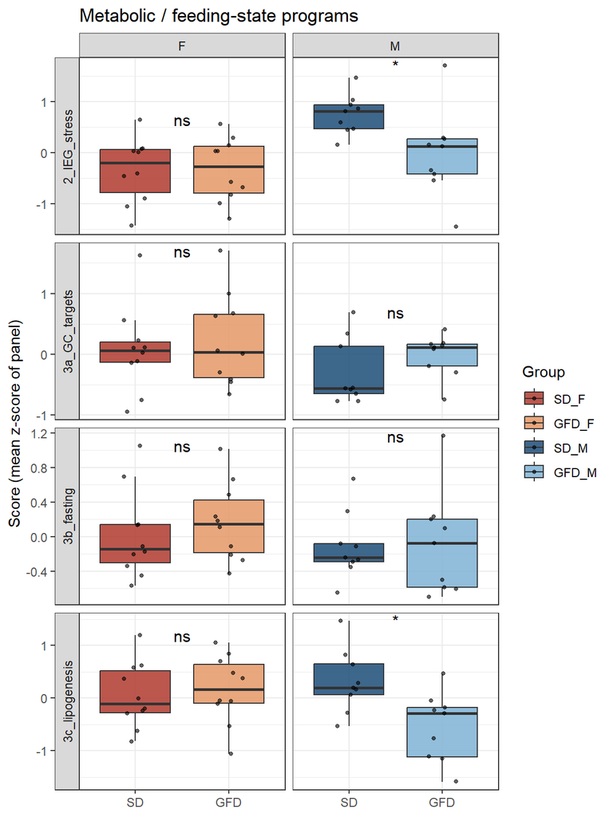

```r
plot_panels(scores, c("2_IEG_stress", "3a_GC_targets", "3b_fasting", "3c_lipogenesis"),
            "Metabolic / feeding-state programs")
```

**Open code**

```r
sc <- scores
panel_names <- c("2_IEG_stress", "3a_GC_targets", "3b_fasting", "3c_lipogenesis")

sc <- as.data.frame(sc[, panel_names, drop = FALSE])

sc_long <- sc %>%
  dplyr::mutate(Group = cd$Group, Diet = cd$Diet, Sex = cd$Sex) %>%
  tidyr::pivot_longer(dplyr::all_of(colnames(sc)),
                      names_to = "panel", values_to = "score") %>%
  dplyr::mutate(panel = factor(panel, levels = colnames(sc)))

pvals <- sc_long %>%
  group_by(panel, Sex) %>%
  summarise(p = wilcox.test(score ~ Diet)$p.value,
            top = max(score, na.rm = TRUE),
            rng = diff(range(score, na.rm = TRUE)),
            .groups = "drop") %>%
  mutate(y = top - 0 * rng,
         label = ifelse(p < 0.001, "***",
                 ifelse(p < 0.01,  "**",
                 ifelse(p < 0.05,  "*", "ns"))))

save(sc_long,pvals,file="../Results/figures/F5D_data_validation.RData")
```

# 8 H5: GFD up-regulates OXPHOS and translation and down-regulates inflammatory programs in males

**Hypothesis.** In the male diet contrast, OXPHOS, respiratory electron transport and ribosome sets are positively enriched, and TNFα/NF-κB, inflammatory response and IFN-γ sets are negatively enriched. The three cholesterol/SREBP sets of H4 are tested in the same run.

**Test.**

- fgsea on the **9 pre-specified sets only**, with BH correction across those sets. The deciding ranking is the Wald statistic of the unshrunk **diet-in-males** contrast, as in P76_3. The interaction ranking is shown for comparison only.

-> Replication means the NES is in the expected direction and padj < α.

**P76_3** (male diet ranking). OXPHOS NES = 3.25, respiratory electron transport 3.33, KEGG ribosome 3.28, TNFα/NF-κB −2.43, inflammatory response −2.04, IFN-γ response −1.72.

**Open code**

```r
get_sets <- function(coll, subcoll = NULL) {
  out <- tryCatch(
    msigdbr(species = "Mus musculus",
            collection = coll, subcollection = subcoll),
    error = function(e) msigdbr(species = "Mus musculus",
                                category = coll,
                                subcategory = subcoll)
  )
  split(out$gene_symbol, out$gs_name)
}

all_sets <- c(get_sets("H"),
              tryCatch(get_sets("C2", "CP:KEGG_LEGACY"),
                       error = function(e) get_sets("C2", "CP:KEGG")),
              get_sets("C2", "CP:REACTOME"))
```

```
Using human MSigDB with ortholog mapping to mouse. Use `db_species = "MM"` for mouse-native gene sets.
```

**Open code**

```r
gsea_expect <- tribble(
  ~pathway,                                                        ~hyp, ~expected,
  "HALLMARK_OXIDATIVE_PHOSPHORYLATION",                            "H5",  1,
  "REACTOME_RESPIRATORY_ELECTRON_TRANSPORT",                       "H5",  1,
  "KEGG_RIBOSOME",                                                 "H5",  1,
  "HALLMARK_TNFA_SIGNALING_VIA_NFKB",                              "H5", -1,
  "HALLMARK_INFLAMMATORY_RESPONSE",                                "H5", -1,
  "HALLMARK_INTERFERON_GAMMA_RESPONSE",                            "H5", -1,
  "HALLMARK_CHOLESTEROL_HOMEOSTASIS",                              "H4", -1,
  "REACTOME_ACTIVATION_OF_GENE_EXPRESSION_BY_SREBF_SREBP",         "H4", -1,
  "REACTOME_REGULATION_OF_CHOLESTEROL_BIOSYNTHESIS_BY_SREBP_SREBF","H4", -1
)

missing_sets <- setdiff(gsea_expect$pathway, names(all_sets))

if (length(missing_sets)) warning("Gene sets not found: ", paste(missing_sets, collapse = ", "))
target_sets <- all_sets[intersect(gsea_expect$pathway, names(all_sets))]
```

**Open code**

```r
# one value per gene symbol (the one with the largest |value|)
make_ranks <- function(res, col = "stat") {
  df <- res_to_df(res) %>%
    dplyr::filter(!is.na(gene_name), gene_name != "", !is.na(.data[[col]])) %>%
    group_by(gene_name) %>% slice_max(abs(.data[[col]]), n = 1, with_ties = FALSE) %>% ungroup()
  sort(setNames(df[[col]], df$gene_name), decreasing = TRUE)
}


run_targeted_gsea <- function(ranks, label) {
  set.seed(123)
  fgsea(target_sets, ranks, minSize = 10, maxSize = 500, eps = 0) %>%
    as_tibble() %>%
    dplyr::select(pathway,  pval, padj,log2err,ES, NES, size, leadingEdge) %>%
    dplyr::mutate(ranking = label)
}

gsea_tab <- bind_rows(
  run_targeted_gsea(make_ranks(res_diet_in_M_wald, col = "stat"), "male diet, Wald stat (secondary)"),
  run_targeted_gsea(make_ranks(res_int_wald,       col = "stat"), "interaction, Wald stat")) %>%
  left_join(gsea_expect, by = "pathway") %>%
  dplyr::mutate(direction_ok = sign(NES) == expected,
                replicated   = direction_ok & padj < alpha) %>%
  dplyr::arrange(ranking, hyp, pathway)

ktab(gsea_tab, "H4/H5: targeted GSEA")
```

H4/H5: targeted GSEA

| pathway | pval | padj | log2err | ES | NES | size | leadingEdge | ranking | hyp | expected | direction_ok | replicated |
| --- | --- | --- | --- | --- | --- | --- | --- | --- | --- | --- | --- | --- |
| HALLMARK_CHOLESTEROL_HOMEOSTASIS | 1.53e-03 | 1.53e-03 | 0.4551 | -0.3410 | -1.695 | 75 | Chka, Sc.... | interaction, Wald stat | H4 | -1 | TRUE | TRUE |
| REACTOME_ACTIVATION_OF_GENE_EXPRESSION_BY_SREBF_SREBP | 9.70e-06 | 1.24e-05 | 0.5933 | -0.5294 | -2.283 | 43 | Scd1, Sc.... | interaction, Wald stat | H4 | -1 | TRUE | TRUE |
| REACTOME_REGULATION_OF_CHOLESTEROL_BIOSYNTHESIS_BY_SREBP_SREBF | 4.00e-06 | 7.10e-06 | 0.6105 | -0.4922 | -2.287 | 56 | Scd1, Sc.... | interaction, Wald stat | H4 | -1 | TRUE | TRUE |
| HALLMARK_INFLAMMATORY_RESPONSE | 5.80e-06 | 8.60e-06 | 0.6105 | -0.3245 | -1.891 | 185 | Cxcl10, .... | interaction, Wald stat | H5 | -1 | TRUE | TRUE |
| HALLMARK_INTERFERON_GAMMA_RESPONSE | 3.68e-05 | 4.14e-05 | 0.5573 | -0.2880 | -1.696 | 199 | Cxcl10, .... | interaction, Wald stat | H5 | -1 | TRUE | TRUE |
| HALLMARK_OXIDATIVE_PHOSPHORYLATION | 0.00e+00 | 0.00e+00 | 1.1950 | 0.5503 | 2.857 | 185 | Cox11, N.... | interaction, Wald stat | H5 | 1 | TRUE | TRUE |
| HALLMARK_TNFA_SIGNALING_VIA_NFKB | 3.10e-06 | 7.00e-06 | 0.6273 | -0.3157 | -1.857 | 198 | Cxcl10, .... | interaction, Wald stat | H5 | -1 | TRUE | TRUE |
| KEGG_RIBOSOME | 0.00e+00 | 0.00e+00 | 1.8650 | 0.8673 | 3.946 | 83 | Rpl13a, .... | interaction, Wald stat | H5 | 1 | TRUE | TRUE |
| REACTOME_RESPIRATORY_ELECTRON_TRANSPORT | 0.00e+00 | 0.00e+00 | 1.6090 | 0.6905 | 3.486 | 152 | Cox11, m.... | interaction, Wald stat | H5 | 1 | TRUE | TRUE |
| HALLMARK_CHOLESTEROL_HOMEOSTASIS | 2.00e-07 | 2.00e-07 | 0.6901 | -0.4829 | -2.275 | 75 | Sqle, Hm.... | male diet, Wald stat (secondary) | H4 | -1 | TRUE | TRUE |
| REACTOME_ACTIVATION_OF_GENE_EXPRESSION_BY_SREBF_SREBP | 0.00e+00 | 0.00e+00 | 0.7195 | -0.6002 | -2.470 | 43 | Sqle, Hm.... | male diet, Wald stat (secondary) | H4 | -1 | TRUE | TRUE |
| REACTOME_REGULATION_OF_CHOLESTEROL_BIOSYNTHESIS_BY_SREBP_SREBF | 1.00e-07 | 1.00e-07 | 0.6901 | -0.5414 | -2.396 | 56 | Sqle, Hm.... | male diet, Wald stat (secondary) | H4 | -1 | TRUE | TRUE |
| HALLMARK_INFLAMMATORY_RESPONSE | 0.00e+00 | 0.00e+00 | 0.8753 | -0.4238 | -2.324 | 185 | Cybb, Cm.... | male diet, Wald stat (secondary) | H5 | -1 | TRUE | TRUE |
| HALLMARK_INTERFERON_GAMMA_RESPONSE | 0.00e+00 | 0.00e+00 | 0.7882 | -0.3844 | -2.139 | 199 | Gbp9, Cm.... | male diet, Wald stat (secondary) | H5 | -1 | TRUE | TRUE |
| HALLMARK_OXIDATIVE_PHOSPHORYLATION | 0.00e+00 | 0.00e+00 | 1.3730 | 0.6078 | 3.028 | 185 | Ndufa6, .... | male diet, Wald stat (secondary) | H5 | 1 | TRUE | TRUE |
| HALLMARK_TNFA_SIGNALING_VIA_NFKB | 0.00e+00 | 0.00e+00 | 0.9653 | -0.4391 | -2.445 | 198 | Cd44, Cx.... | male diet, Wald stat (secondary) | H5 | -1 | TRUE | TRUE |
| KEGG_RIBOSOME | 0.00e+00 | 0.00e+00 | 1.7860 | 0.8604 | 3.755 | 83 | Rps2, Rp.... | male diet, Wald stat (secondary) | H5 | 1 | TRUE | TRUE |
| REACTOME_RESPIRATORY_ELECTRON_TRANSPORT | 0.00e+00 | 0.00e+00 | 1.7450 | 0.7323 | 3.543 | 152 | mt-Nd3, .... | male diet, Wald stat (secondary) | H5 | 1 | TRUE | TRUE |

**Open code**

```r
prim <- dplyr::filter(
  gsea_tab,
  ranking == "male diet, Wald stat (secondary)")

for (i in seq_len(nrow(prim))) {
  log_result(prim$hyp[i], "secondary",
             paste("GSEA", prim$pathway[i]), "fgsea, BH over target sets",
             "dir", ifelse(prim$expected[i] > 0, ">0", "<0"),
             estimate = prim$NES[i],
             p = ifelse(prim$direction_ok[i], prim$padj[i], 1))
}
```

**Open code**

```r
write.xlsx(gsea_tab,"../Results/validation_P76_4/gsea_results.xlsx")
```

### 8.0.1 Results

**Open code**

```r
bind_rows(results_log) %>%
  dplyr::filter(id == "H4" & grepl("fgsea",test)) %>%
  ktab("H4: cholesterol/SREBP gene sets in the male diet ranking")
```

H4: cholesterol/SREBP gene sets in the male diet ranking

| id | tier | what | test | type | expected | P76_3 | P76_4 | p | note |
| --- | --- | --- | --- | --- | --- | --- | --- | --- | --- |
| H4 | secondary | GSEA HALLMARK_CHOLESTEROL_HOMEOSTASIS | fgsea, BH over target sets | dir | <0 | NA | -2.275 | 2e-07 |  |
| H4 | secondary | GSEA REACTOME_ACTIVATION_OF_GENE_EXPRESSION_BY_SREBF_SREBP | fgsea, BH over target sets | dir | <0 | NA | -2.470 | 0e+00 |  |
| H4 | secondary | GSEA REACTOME_REGULATION_OF_CHOLESTEROL_BIOSYNTHESIS_BY_SREBP_SREBF | fgsea, BH over target sets | dir | <0 | NA | -2.396 | 1e-07 |  |

**Open code**

```r
bind_rows(results_log) %>%
  dplyr::filter(id == "H5") %>%
  ktab("H5: OXPHOS/translation up and inflammatory programs down in GFD males")
```

H5: OXPHOS/translation up and inflammatory programs down in GFD males

| id | tier | what | test | type | expected | P76_3 | P76_4 | p | note |
| --- | --- | --- | --- | --- | --- | --- | --- | --- | --- |
| H5 | secondary | GSEA HALLMARK_INFLAMMATORY_RESPONSE | fgsea, BH over target sets | dir | <0 | NA | -2.324 | 0 |  |
| H5 | secondary | GSEA HALLMARK_INTERFERON_GAMMA_RESPONSE | fgsea, BH over target sets | dir | <0 | NA | -2.139 | 0 |  |
| H5 | secondary | GSEA HALLMARK_OXIDATIVE_PHOSPHORYLATION | fgsea, BH over target sets | dir | >0 | NA | 3.028 | 0 |  |
| H5 | secondary | GSEA HALLMARK_TNFA_SIGNALING_VIA_NFKB | fgsea, BH over target sets | dir | <0 | NA | -2.445 | 0 |  |
| H5 | secondary | GSEA KEGG_RIBOSOME | fgsea, BH over target sets | dir | >0 | NA | 3.755 | 0 |  |
| H5 | secondary | GSEA REACTOME_RESPIRATORY_ELECTRON_TRANSPORT | fgsea, BH over target sets | dir | >0 | NA | 3.543 | 0 |  |

# 9 H6: Diet amplifies sexual dimorphism

**Hypothesis.** GFD widens the male–female difference in hepatic expression, and the change is carried by the male diet response. In P76_3, 564 genes were sex-DE under SD and 6129 under GFD.

**Tests.** The gene set for tests 1 and 2 is the union of P76_3 sex-DE genes (SD or GFD).

1. *Amplification (deciding test):* |sex LFC on GFD| > |sex LFC on SD| (paired Wilcoxon, one-sided).
2. *Carried by males:* |diet LFC in males| > |diet LFC in females| (paired Wilcoxon, one-sided). Because (sex on GFD − sex on SD) = (diet in males − diet in females), this asks which sex the change in dimorphism comes from.
3. *Agreement with P76_3:* the sign of the sex LFC on GFD agrees with P76_3 for more than 50% of the P76_3 “Sex effect in GFD” genes (binomial, one-sided, analogous to H2).

Tests 1 and 2 use **unshrunk** DESeq2 LFCs. ashr fits its prior separately for each contrast, so a contrast with little genome-wide signal (diet in females: 0 DEGs) is shrunk towards 0 almost everywhere, which would bias a magnitude comparison between contrasts. The four contrasts have similar standard errors (cells of 10/9 animals), so the raw LFCs are comparable. Test 3 uses only the sign, so the shrunk LFCs are used there.

**Open code**

```r
# P76_3 sex-DE gene tables (written by summarise_res())
disc_sex_SD  <- read.xlsx(file.path(paths$disc_dir, "Sex effect in SD.xlsx"))
disc_sex_GFD <- read.xlsx(file.path(paths$disc_dir, "Sex effect in GFD.xlsx"))

# gene set for tests 1 and 2: union of P76_3 sex-DE genes (SD or GFD)
disc_sex <- bind_rows(
  disc_sex_SD  %>% dplyr::select(gene_id, gene_name) %>% dplyr::mutate(source = "SD"),
  disc_sex_GFD %>% dplyr::select(gene_id, gene_name) %>% dplyr::mutate(source = "GFD")
) %>%
  dplyr::group_by(gene_id, gene_name) %>%
  dplyr::summarise(source = paste(sort(unique(source)), collapse = "+"), .groups = "drop")

# P76_4 ashr-shrunk LFCs for the four simple contrasts (used for the sign test, test 3)
lfc4 <-res_to_df(res_sex_in_SD)  %>%
  dplyr::select(gene_id, sex_SD  = log2FoldChange) %>%
  inner_join(res_to_df(res_sex_in_GFD) %>% dplyr::select(gene_id, sex_GFD = log2FoldChange), by = "gene_id") %>%
  inner_join(res_to_df(res_diet_in_M)  %>% dplyr::select(gene_id, diet_M  = log2FoldChange), by = "gene_id") %>%
  inner_join(res_to_df(res_diet_in_F)  %>% dplyr::select(gene_id, diet_F  = log2FoldChange), by = "gene_id")

# P76_4 unshrunk LFCs for the same contrasts (used for the magnitude tests, tests 1 and 2)
raw <- function(...) res_to_df(results(dds, ...))
lfc4_raw <- raw(name = "Sex_M_vs_F") %>% dplyr::select(gene_id, sex_SD = log2FoldChange) %>%
  inner_join(raw(contrast = list(c("Sex_M_vs_F", "DietGFD.SexM"))) %>% dplyr::select(gene_id, sex_GFD = log2FoldChange), by = "gene_id") %>%
  inner_join(raw(contrast = list(c("Diet_GFD_vs_SD", "DietGFD.SexM"))) %>% dplyr::select(gene_id, diet_M = log2FoldChange), by = "gene_id") %>%
  inner_join(raw(name = "Diet_GFD_vs_SD") %>% dplyr::select(gene_id, diet_F = log2FoldChange), by = "gene_id")

dimorph <- disc_sex %>%
  inner_join(lfc4_raw, by = "gene_id") %>%
  dplyr::filter(if_all(c(sex_SD, sex_GFD, diet_M, diet_F), ~ !is.na(.x)))

cat("P76_3 sex-DE genes (union):", nrow(disc_sex),
    "| found in P76_4:", nrow(dimorph), "\n")
```

```
P76_3 sex-DE genes (union): 6199 | found in P76_4: 5938
```

**Open code**

```r
# paired one-sided Wilcoxon: is a > b?
paired_greater <- function(a, b, label) {
  wt <- wilcox.test(a, b, paired = TRUE, alternative = "greater",
                    conf.int = TRUE, exact = FALSE)
  tibble(test          = label,
         n_genes       = length(a),
         median_a      = median(a),
         median_b      = median(b),
         pseudo_median = unname(wt$estimate),   # Hodges-Lehmann of a - b
         frac_a_gt_b   = mean(a > b),
         p             = wt$p.value)
}

# Test 1 - amplification: |sex LFC on GFD| > |sex LFC on SD|
t1 <- paired_greater(abs(dimorph$sex_GFD), abs(dimorph$sex_SD),
                     "abs(sex LFC GFD) > abs(sex LFC SD)")

# Test 2 - carried by males: |diet LFC in males| > |diet LFC in females|
t2 <- paired_greater(abs(dimorph$diet_M), abs(dimorph$diet_F),
                     "abs(diet LFC M) > abs(diet LFC F)")

# Test 3 - agreement with discovery: sign of sex LFC on GFD, P76_4 vs P76_3
# (analogous to H2; gene set = P76_3 "Sex effect in GFD" genes)
cmp_sexGFD <- disc_sex_GFD %>%
  dplyr::select(gene_id, gene_name, lfc_disc = log2FoldChange) %>%
  inner_join(lfc4 %>% dplyr::select(gene_id, lfc_val = sex_GFD), by = "gene_id") %>%
  dplyr::filter(!is.na(lfc_val))

k_conc <- sum(sign(cmp_sexGFD$lfc_val) == sign(cmp_sexGFD$lfc_disc))
n_conc <- nrow(cmp_sexGFD)
b3     <- binom.test(k_conc, n_conc, 0.5, alternative = "greater")
rho3   <- suppressWarnings(cor.test(cmp_sexGFD$lfc_disc, cmp_sexGFD$lfc_val,
                                    method = "spearman", alternative = "greater"))

t3 <- tibble(test = "sign concordance, sex LFC on GFD (P76_4 vs P76_3)",
             n_genes = n_conc, concordance = k_conc / n_conc, p = b3$p.value,
             rho = unname(rho3$estimate), p_rho = rho3$p.value)

ktab(bind_rows(t1, t2), "H6: paired Wilcoxon tests (one-sided)")
```

H6: paired Wilcoxon tests (one-sided)

| test | n_genes | median_a | median_b | pseudo_median | frac_a_gt_b | p |
| --- | --- | --- | --- | --- | --- | --- |
| abs(sex LFC GFD) > abs(sex LFC SD) | 5938 | 0.7260 | 0.4348 | 0.2893 | 0.7098 | 0 |
| abs(diet LFC M) > abs(diet LFC F) | 5938 | 0.8613 | 0.1867 | 0.6192 | 0.8567 | 0 |

**Open code**

```r
ktab(t3, "H6: sign concordance with P76_3 (binomial, one-sided)")
```

H6: sign concordance with P76_3 (binomial, one-sided)

| test | n_genes | concordance | p | rho | p_rho |
| --- | --- | --- | --- | --- | --- |
| sign concordance, sex LFC on GFD (P76_4 vs P76_3) | 5869 | 0.9344 | 0 | 0.8163 | 0 |

### 9.0.1 Results

**Open code**

```r
log_result("H6", "primary",
           "Amplification: abs(sex LFC GFD) > abs(sex LFC SD) (P76_3 sex-DE genes)",
           "paired Wilcoxon, one-sided", "dir", ">0",
           estimate = t1$pseudo_median, p = t1$p,
           note = sprintf("n = %d; %.0f%% genes larger on GFD",
                          t1$n_genes, 100 * t1$frac_a_gt_b))

log_result("H6", "secondary",
           "Carried by males: abs(diet LFC M) > abs(diet LFC F) (P76_3 sex-DE genes)",
           "paired Wilcoxon, one-sided", "dir", ">0",
           estimate = t2$pseudo_median, p = t2$p,
           note = sprintf("n = %d; %.0f%% genes larger in males",
                          t2$n_genes, 100 * t2$frac_a_gt_b))

log_result("H6", "secondary",
           "Agreement with P76_3: sign of sex LFC on GFD",
           "binomial, one-sided", "dir", ">0.5",
           estimate = t3$concordance, p = t3$p,
           note = sprintf("n = %d; Spearman rho = %.2f (p = %.2g)",
                          t3$n_genes, t3$rho, t3$p_rho))

bind_rows(results_log) %>%
  dplyr::filter(id == "H6") %>%
  ktab("H6: Diet amplifies sexual dimorphism")
```

H6: Diet amplifies sexual dimorphism

| id | tier | what | test | type | expected | P76_3 | P76_4 | p | note |
| --- | --- | --- | --- | --- | --- | --- | --- | --- | --- |
| H6 | primary | Amplification: abs(sex LFC GFD) > abs(sex LFC SD) (P76_3 sex-DE genes) | paired Wilcoxon, one-sided | dir | >0 | NA | 0.2893 | 0 | n = 5938; 71% genes larger on GFD |
| H6 | secondary | Carried by males: abs(diet LFC M) > abs(diet LFC F) (P76_3 sex-DE genes) | paired Wilcoxon, one-sided | dir | >0 | NA | 0.6192 | 0 | n = 5938; 86% genes larger in males |
| H6 | secondary | Agreement with P76_3: sign of sex LFC on GFD | binomial, one-sided | dir | >0.5 | NA | 0.9344 | 0 | n = 5869; Spearman rho = 0.82 (p = 0) |

## 9.1 Visualization

**Open code**

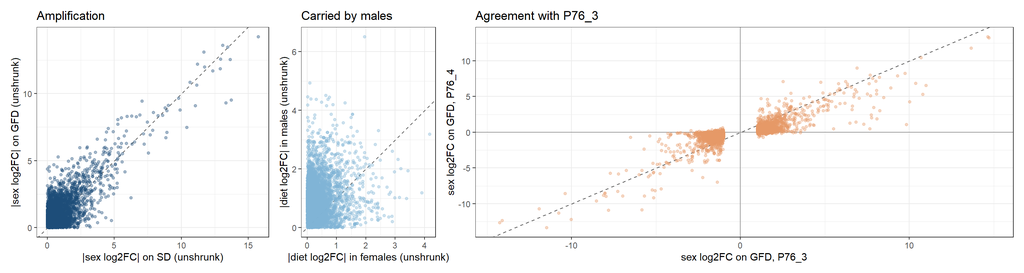

```r
# Visualization
p_amp <- ggplot(dimorph, aes(abs(sex_SD), abs(sex_GFD))) +
  geom_abline(linetype = "dashed", colour = "grey40") +
  geom_point(alpha = 0.4, size = 1.2, colour = "#1c4c78") +
  labs(x = "|sex log2FC| on SD (unshrunk)", y = "|sex log2FC| on GFD (unshrunk)",
       title = "Amplification") +
  coord_equal() + theme_bw()

p_male <- ggplot(dimorph, aes(abs(diet_F), abs(diet_M))) +
  geom_abline(linetype = "dashed", colour = "grey40") +
  geom_point(alpha = 0.4, size = 1.2, colour = "#7fb3d5") +
  labs(x = "|diet log2FC| in females (unshrunk)", y = "|diet log2FC| in males (unshrunk)",
       title = "Carried by males") +
  coord_equal() + theme_bw()

p_conc <- ggplot(cmp_sexGFD, aes(lfc_disc, lfc_val)) +
  geom_hline(yintercept = 0, colour = "grey60") +
  geom_vline(xintercept = 0, colour = "grey60") +
  geom_abline(linetype = "dashed", colour = "grey40") +
  geom_point(alpha = 0.4, size = 1.2, colour = "#e59866") +
  labs(x = "sex log2FC on GFD, P76_3", y = "sex log2FC on GFD, P76_4",
       title = "Agreement with P76_3") +
  theme_bw()

p_amp + p_male + p_conc
```

# 10 H7 and H8: Liver-damage panels

**H7 (exploratory).** Ductular (6) and cholestasis (8) panels: Diet×Sex interaction < 0, i.e. the diet effect on these scores is more negative in males than in females.

**P76_3.** Interaction: ductular −0.659, cholestasis −0.132.

**H8 (exploratory).** Fibrosis markers are lower in GFD males than in SD males.

**P76_3.** GFD_M − SD_M = −0.757.

The 7_inflammation panel is shown for context; it has no pre-specified test.

**Open code**

```r
h7 <- pc %>%
  dplyr::filter(panel %in%
                  c("5_fibrosis", "6_ductular", "7_inflammation", "8_cholestasis")) %>%
  left_join(disc_ref, by = c("panel", "contrast"))

ktab(h7, "H7/H8: liver-damage panel contrasts (P76_3 panel mapping)")
```

H7/H8: liver-damage panel contrasts (P76_3 panel mapping)

| panel | contrast | estimate | SE | df | t.ratio | p.value | P76_3 |
| --- | --- | --- | --- | --- | --- | --- | --- |
| 5_fibrosis | diet_in_F | -0.33530 | 0.2709 | 33 | -1.23800 | 0.2246000 | NA |
| 5_fibrosis | diet_in_M | -1.10100 | 0.2890 | 33 | -3.80900 | 0.0005761 | -0.7565 |
| 5_fibrosis | sex_in_SD | 0.03322 | 0.2786 | 33 | 0.11930 | 0.9058000 | -0.5109 |
| 5_fibrosis | sex_in_GFD | -0.73230 | 0.2803 | 33 | -2.61200 | 0.0134300 | NA |
| 5_fibrosis | interaction | -0.76560 | 0.3961 | 33 | -1.93300 | 0.0619000 | NA |
| 6_ductular | diet_in_F | -0.01895 | 0.2914 | 33 | -0.06504 | 0.9485000 | NA |
| 6_ductular | diet_in_M | -0.75280 | 0.3108 | 33 | -2.42200 | 0.0210800 | NA |
| 6_ductular | sex_in_SD | -0.22710 | 0.2996 | 33 | -0.75820 | 0.4537000 | NA |
| 6_ductular | sex_in_GFD | -0.96100 | 0.3015 | 33 | -3.18800 | 0.0031320 | NA |
| 6_ductular | interaction | -0.73390 | 0.4260 | 33 | -1.72300 | 0.0943100 | -0.6591 |
| 7_inflammation | diet_in_F | 0.01735 | 0.2471 | 33 | 0.07021 | 0.9444000 | NA |
| 7_inflammation | diet_in_M | -0.30150 | 0.2636 | 33 | -1.14300 | 0.2611000 | NA |
| 7_inflammation | sex_in_SD | -0.20370 | 0.2541 | 33 | -0.80150 | 0.4286000 | NA |
| 7_inflammation | sex_in_GFD | -0.52250 | 0.2557 | 33 | -2.04300 | 0.0491000 | NA |
| 7_inflammation | interaction | -0.31880 | 0.3614 | 33 | -0.88220 | 0.3840000 | NA |
| 8_cholestasis | diet_in_F | -0.07773 | 0.1361 | 33 | -0.57110 | 0.5718000 | NA |
| 8_cholestasis | diet_in_M | -0.11280 | 0.1452 | 33 | -0.77710 | 0.4426000 | NA |
| 8_cholestasis | sex_in_SD | -0.06348 | 0.1399 | 33 | -0.45360 | 0.6531000 | NA |
| 8_cholestasis | sex_in_GFD | -0.09857 | 0.1408 | 33 | -0.69990 | 0.4889000 | NA |
| 8_cholestasis | interaction | -0.03509 | 0.1990 | 33 | -0.17630 | 0.8611000 | -0.1323 |

**Open code**

```r
for (pn in c("6_ductular", "8_cholestasis")) {
  r <- get_c(pc, pn, "interaction")
  log_result("H7", "exploratory",
             paste0(pn, ": Diet×Sex interaction"),
             "lm + emmeans, one-sided",
             "dir", "<0",
             estimate = r$estimate,
             p = p_dir(r$t.ratio, r$df, -1),
             disc = disc_ref$P76_3[disc_ref$panel == pn & disc_ref$contrast == "interaction"])
}

r <- get_c(pc, "5_fibrosis", "diet_in_M")

log_result("H8", "exploratory",
           "5_fibrosis: GFD_M − SD_M", "lm + emmeans, one-sided",
           "dir", "<0",
           estimate = r$estimate,
           p = p_dir(r$t.ratio, r$df, -1),
           disc =  disc_ref$P76_3[disc_ref$panel == "5_fibrosis" & disc_ref$contrast == "diet_in_M"])
```

## 10.1 Results

**Open code**

```r
bind_rows(results_log) %>%
  dplyr::filter(id == "H7") %>%
  ktab("H7: Ductular (6) and cholestasis (8) panels: Diet×Sex interaction < 0.")
```

H7: Ductular (6) and cholestasis (8) panels: Diet×Sex interaction < 0.

| id | tier | what | test | type | expected | P76_3 | P76_4 | p | note |
| --- | --- | --- | --- | --- | --- | --- | --- | --- | --- |
| H7 | exploratory | 6_ductular: Diet×Sex interaction | lm + emmeans, one-sided | dir | <0 | -0.6591 | -0.73390 | 0.04715 |  |
| H7 | exploratory | 8_cholestasis: Diet×Sex interaction | lm + emmeans, one-sided | dir | <0 | -0.1323 | -0.03509 | 0.43050 |  |

**Open code**

```r
bind_rows(results_log) %>%
  dplyr::filter(id == "H8") %>%
  ktab("H8: Fibrosis markers are lower in GFD males than in SD males.")
```

H8: Fibrosis markers are lower in GFD males than in SD males.

| id | tier | what | test | type | expected | P76_3 | P76_4 | p | note |
| --- | --- | --- | --- | --- | --- | --- | --- | --- | --- |
| H8 | exploratory | 5_fibrosis: GFD_M − SD_M | lm + emmeans, one-sided | dir | <0 | -0.7565 | -1.101 | 0.000288 |  |

**Open code**

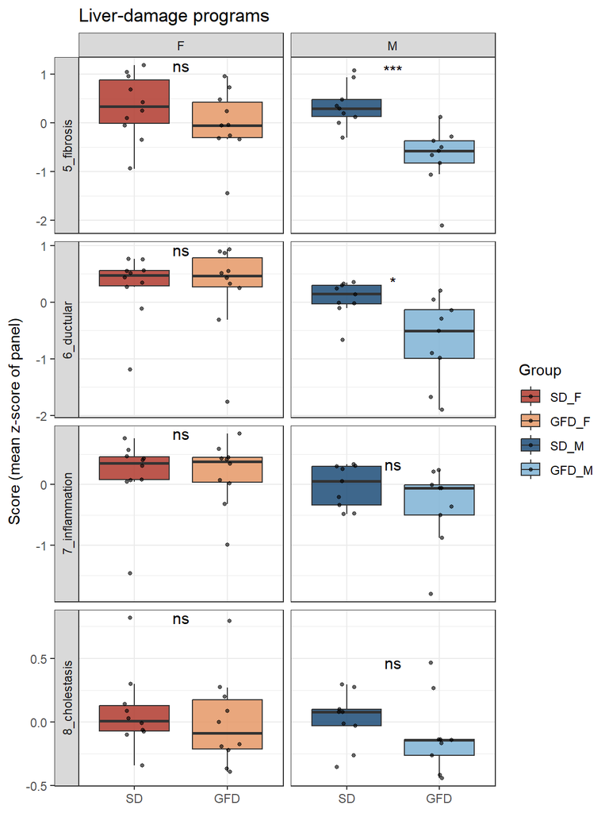

```r
plot_panels(scores, c("5_fibrosis", "6_ductular", "7_inflammation", "8_cholestasis"),
            "Liver-damage programs")
```

## 10.2 Panel tests

**Open code**

```r
program_panels <- names(panels_sym)

# score = mean z-score of gene panels for each samples
scores <- sapply(program_panels, function(nm) {
   colMeans(z[panels[[nm]], , drop = FALSE], na.rm = TRUE)
})

colnames(scores) <- program_panels

# masculinization index:
# male-female program (1 axis, direct feminization test)
scores <- cbind(scores,
                masc_index = scores[, "1a_male_liver"] - scores[, "1b_female_liver"])

test_program <- function(sc, name, cd) {
  fit <- lm(sc ~ Diet * Sex + Date, data = cbind(cd, sc = sc))
  emm <- emmeans(fit, ~ Diet * Sex)
  # cell order in emm: SD_F, GFD_F, SD_M, GFD_M  (check with print(emm))

  ctr <- list(
    diet_in_F   = c(-1,  1,  0, 0),   # GFD_F - SD_F
    diet_in_M   = c( 0,  0, -1, 1),   # GFD_M - SD_M
    sex_in_SD   = c(-1,  0,  1, 0),   # SD_M  - SD_F
    sex_in_GFD  = c( 0, -1,  0, 1),   # GFD_M - GFD_F
    interaction = c( 1, -1, -1, 1)    # (GFD_M - SD_M) - (GFD_F - SD_F)
  )

  res <- summary(contrast(emm, method = ctr, adjust = "none"),
                 infer = TRUE, level = 0.95)

  data.frame(
    Panel      = name,
    Contrast   = res$contrast,
    Estimate   = res$estimate,
    SE         = res$SE,
    df         = res$df,
    t          = res$t.ratio,
    p          = res$p.value,
    CI_lower   = res$lower.CL,
    CI_upper   = res$upper.CL
  )
}

a4_tab <- do.call(rbind,
                  lapply(colnames(scores),
                         function(nm) test_program(scores[, nm], nm, cd)))

a4_tab$p_BH <- ave(a4_tab$p, a4_tab$Contrast,
                   FUN = function(p) p.adjust(p, method = "BH"))

a4_tab %>%
  kable(
    caption = "Diet and sex effects on liver program scores. Linear model score ~ Diet × Sex + Date; estimates are differences in mean z-score (GFD − SD for diet, M − F for sex; interaction = diet effect in males − diet effect in females), with unadjusted two-sided p values and 95% confidence intervals.",
    digits   = 3,
    booktabs = TRUE,
    align    = "llccccccc"
  ) %>%
  kable_styling(
    latex_options     = c("hold_position"),
    bootstrap_options = c("striped", "hover", "condensed")
  )
```

Diet and sex effects on liver program scores. Linear model score ~ Diet × Sex + Date; estimates are differences in mean z-score (GFD − SD for diet, M − F for sex; interaction = diet effect in males − diet effect in females), with unadjusted two-sided p values and 95% confidence intervals.

| Panel | Contrast | Estimate | SE | df | t | p | CI_lower | CI_upper | p_BH |
| --- | --- | --- | --- | --- | --- | --- | --- | --- | --- |
| 1a_male_liver | diet_in_F | -0.071 | 0.169 | 33 | -0.422 | 0.676 | -0.415 | 0.273 | 0.981 |
| 1a_male_liver | diet_in_M | 0.451 | 0.180 | 33 | 2.503 | 0.017 | 0.085 | 0.818 | 0.047 |
| 1a_male_liver | sex_in_SD | 1.328 | 0.174 | 33 | 7.642 | 0.000 | 0.974 | 1.682 | 0.000 |
| 1a_male_liver | sex_in_GFD | 1.851 | 0.175 | 33 | 10.583 | 0.000 | 1.495 | 2.206 | 0.000 |
| 1a_male_liver | interaction | 0.523 | 0.247 | 33 | 2.115 | 0.042 | 0.020 | 1.025 | 0.201 |
| 1b_female_liver | diet_in_F | -0.124 | 0.137 | 33 | -0.906 | 0.371 | -0.404 | 0.155 | 0.981 |
| 1b_female_liver | diet_in_M | 0.037 | 0.147 | 33 | 0.250 | 0.804 | -0.262 | 0.335 | 0.880 |
| 1b_female_liver | sex_in_SD | -1.751 | 0.141 | 33 | -12.397 | 0.000 | -2.039 | -1.464 | 0.000 |
| 1b_female_liver | sex_in_GFD | -1.590 | 0.142 | 33 | -11.185 | 0.000 | -1.879 | -1.301 | 0.000 |
| 1b_female_liver | interaction | 0.161 | 0.201 | 33 | 0.802 | 0.428 | -0.248 | 0.570 | 0.618 |
| 1c_GH_STAT5 | diet_in_F | 0.007 | 0.189 | 33 | 0.038 | 0.970 | -0.377 | 0.391 | 0.981 |
| 1c_GH_STAT5 | diet_in_M | -0.420 | 0.201 | 33 | -2.089 | 0.045 | -0.830 | -0.011 | 0.083 |
| 1c_GH_STAT5 | sex_in_SD | 0.131 | 0.194 | 33 | 0.673 | 0.506 | -0.264 | 0.525 | 0.657 |
| 1c_GH_STAT5 | sex_in_GFD | -0.297 | 0.195 | 33 | -1.521 | 0.138 | -0.694 | 0.100 | 0.199 |
| 1c_GH_STAT5 | interaction | -0.428 | 0.276 | 33 | -1.549 | 0.131 | -0.989 | 0.134 | 0.243 |
| 2_IEG_stress | diet_in_F | 0.007 | 0.289 | 33 | 0.024 | 0.981 | -0.582 | 0.596 | 0.981 |
| 2_IEG_stress | diet_in_M | -0.744 | 0.309 | 33 | -2.411 | 0.022 | -1.373 | -0.116 | 0.047 |
| 2_IEG_stress | sex_in_SD | 1.081 | 0.298 | 33 | 3.633 | 0.001 | 0.476 | 1.687 | 0.003 |
| 2_IEG_stress | sex_in_GFD | 0.330 | 0.299 | 33 | 1.101 | 0.279 | -0.279 | 0.939 | 0.329 |
| 2_IEG_stress | interaction | -0.751 | 0.423 | 33 | -1.776 | 0.085 | -1.612 | 0.110 | 0.204 |
| 3a_GC_targets | diet_in_F | 0.154 | 0.275 | 33 | 0.559 | 0.580 | -0.405 | 0.712 | 0.981 |
| 3a_GC_targets | diet_in_M | 0.235 | 0.293 | 33 | 0.802 | 0.428 | -0.361 | 0.831 | 0.575 |
| 3a_GC_targets | sex_in_SD | -0.359 | 0.282 | 33 | -1.270 | 0.213 | -0.933 | 0.216 | 0.462 |
| 3a_GC_targets | sex_in_GFD | -0.277 | 0.284 | 33 | -0.975 | 0.337 | -0.855 | 0.301 | 0.365 |
| 3a_GC_targets | interaction | 0.082 | 0.402 | 33 | 0.203 | 0.840 | -0.736 | 0.899 | 0.861 |
| 3b_fasting | diet_in_F | 0.148 | 0.213 | 33 | 0.696 | 0.491 | -0.285 | 0.581 | 0.981 |
| 3b_fasting | diet_in_M | -0.035 | 0.227 | 33 | -0.155 | 0.878 | -0.497 | 0.426 | 0.880 |
| 3b_fasting | sex_in_SD | -0.116 | 0.219 | 33 | -0.530 | 0.600 | -0.561 | 0.329 | 0.708 |
| 3b_fasting | sex_in_GFD | -0.299 | 0.220 | 33 | -1.359 | 0.183 | -0.747 | 0.149 | 0.238 |
| 3b_fasting | interaction | -0.183 | 0.311 | 33 | -0.589 | 0.560 | -0.816 | 0.450 | 0.669 |
| 3c_lipogenesis | diet_in_F | 0.107 | 0.284 | 33 | 0.375 | 0.710 | -0.472 | 0.685 | 0.981 |
| 3c_lipogenesis | diet_in_M | -0.897 | 0.303 | 33 | -2.958 | 0.006 | -1.514 | -0.280 | 0.025 |
| 3c_lipogenesis | sex_in_SD | 0.267 | 0.292 | 33 | 0.914 | 0.367 | -0.327 | 0.862 | 0.655 |
| 3c_lipogenesis | sex_in_GFD | -0.736 | 0.294 | 33 | -2.504 | 0.017 | -1.335 | -0.138 | 0.038 |
| 3c_lipogenesis | interaction | -1.004 | 0.416 | 33 | -2.415 | 0.021 | -1.849 | -0.158 | 0.201 |
| 4_circadian | diet_in_F | 0.224 | 0.222 | 33 | 1.010 | 0.320 | -0.227 | 0.675 | 0.981 |
| 4_circadian | diet_in_M | 0.036 | 0.236 | 33 | 0.153 | 0.880 | -0.445 | 0.517 | 0.880 |
| 4_circadian | sex_in_SD | 0.579 | 0.228 | 33 | 2.543 | 0.016 | 0.116 | 1.043 | 0.041 |
| 4_circadian | sex_in_GFD | 0.392 | 0.229 | 33 | 1.708 | 0.097 | -0.075 | 0.858 | 0.158 |
| 4_circadian | interaction | -0.188 | 0.324 | 33 | -0.579 | 0.566 | -0.847 | 0.471 | 0.669 |
| 5_fibrosis | diet_in_F | -0.335 | 0.271 | 33 | -1.238 | 0.225 | -0.887 | 0.216 | 0.981 |
| 5_fibrosis | diet_in_M | -1.101 | 0.289 | 33 | -3.809 | 0.001 | -1.689 | -0.513 | 0.007 |
| 5_fibrosis | sex_in_SD | 0.033 | 0.279 | 33 | 0.119 | 0.906 | -0.534 | 0.600 | 0.906 |
| 5_fibrosis | sex_in_GFD | -0.732 | 0.280 | 33 | -2.612 | 0.013 | -1.303 | -0.162 | 0.035 |
| 5_fibrosis | interaction | -0.766 | 0.396 | 33 | -1.933 | 0.062 | -1.571 | 0.040 | 0.201 |
| 6_ductular | diet_in_F | -0.019 | 0.291 | 33 | -0.065 | 0.949 | -0.612 | 0.574 | 0.981 |
| 6_ductular | diet_in_M | -0.753 | 0.311 | 33 | -2.422 | 0.021 | -1.385 | -0.121 | 0.047 |
| 6_ductular | sex_in_SD | -0.227 | 0.300 | 33 | -0.758 | 0.454 | -0.837 | 0.382 | 0.655 |
| 6_ductular | sex_in_GFD | -0.961 | 0.301 | 33 | -3.188 | 0.003 | -1.574 | -0.348 | 0.010 |
| 6_ductular | interaction | -0.734 | 0.426 | 33 | -1.723 | 0.094 | -1.601 | 0.133 | 0.204 |
| 7_inflammation | diet_in_F | 0.017 | 0.247 | 33 | 0.070 | 0.944 | -0.485 | 0.520 | 0.981 |
| 7_inflammation | diet_in_M | -0.301 | 0.264 | 33 | -1.143 | 0.261 | -0.838 | 0.235 | 0.424 |
| 7_inflammation | sex_in_SD | -0.204 | 0.254 | 33 | -0.801 | 0.429 | -0.721 | 0.313 | 0.655 |
| 7_inflammation | sex_in_GFD | -0.522 | 0.256 | 33 | -2.043 | 0.049 | -1.043 | -0.002 | 0.091 |
| 7_inflammation | interaction | -0.319 | 0.361 | 33 | -0.882 | 0.384 | -1.054 | 0.416 | 0.618 |
| 8_cholestasis | diet_in_F | -0.078 | 0.136 | 33 | -0.571 | 0.572 | -0.355 | 0.199 | 0.981 |
| 8_cholestasis | diet_in_M | -0.113 | 0.145 | 33 | -0.777 | 0.443 | -0.408 | 0.183 | 0.575 |
| 8_cholestasis | sex_in_SD | -0.063 | 0.140 | 33 | -0.454 | 0.653 | -0.348 | 0.221 | 0.708 |
| 8_cholestasis | sex_in_GFD | -0.099 | 0.141 | 33 | -0.700 | 0.489 | -0.385 | 0.188 | 0.489 |
| 8_cholestasis | interaction | -0.035 | 0.199 | 33 | -0.176 | 0.861 | -0.440 | 0.370 | 0.861 |
| masc_index | diet_in_F | 0.053 | 0.123 | 33 | 0.432 | 0.668 | -0.197 | 0.304 | 0.981 |
| masc_index | diet_in_M | 0.415 | 0.131 | 33 | 3.156 | 0.003 | 0.147 | 0.682 | 0.022 |
| masc_index | sex_in_SD | 3.079 | 0.127 | 33 | 24.317 | 0.000 | 2.822 | 3.337 | 0.000 |
| masc_index | sex_in_GFD | 3.441 | 0.127 | 33 | 27.000 | 0.000 | 3.182 | 3.700 | 0.000 |
| masc_index | interaction | 0.361 | 0.180 | 33 | 2.007 | 0.053 | -0.005 | 0.728 | 0.201 |

**Open code**

```r
write.xlsx(a4_tab,
           "../Results/panel_tests_P4.xlsx",
           rownames=FALSE)
```

**Open code**

```r
sc_long <- as.data.frame(scores) %>%
  dplyr::mutate(Group = cd$Group, Diet = cd$Diet, Sex = cd$Sex) %>%
  tidyr::pivot_longer(dplyr::all_of(colnames(scores)),
                      names_to = "panel", values_to = "score") %>%
  dplyr::mutate(panel = factor(panel, levels = colnames(scores)))
```

**Open code**

```r
save(sc_long,file="../Results/figures/FS4_data_validation.RData")
```

# 11 Summary

**Open code**

```r
summary_tab <- bind_rows(results_log)

prim <- summary_tab$tier == "primary"
sign_ok <- function(expected, est) {
  dplyr::case_when(expected %in% c(">0") ~ est > 0,
                   expected %in% c("<0") ~ est < 0,
                   expected == ">0.5"    ~ est > 0.5,
                   expected == "<1"      ~ est < 1,
                   TRUE ~ NA)
}

summary_tab <- summary_tab %>%
  dplyr::mutate(
    p_decide = p,
    ok_dir   = sign_ok(expected, P76_4),
    verdict  = dplyr::case_when(
      type == "dir"  & ok_dir & p_decide <  alpha ~ "replicated",
      type == "dir"  & ok_dir & p_decide >= alpha ~ "same direction, n.s.",
      type == "dir"  & !ok_dir                    ~ "opposite direction",
      type == "tost" & p <  alpha                 ~ "equivalent",
      type == "tost" & p >= alpha                 ~ "inconclusive",
      type == "null" & p >= alpha                 ~ "holds",
      type == "null" & p <  alpha                 ~ "violated",
      TRUE ~ "NA")
  ) %>%
  dplyr::mutate(tier = factor(tier, levels = c("primary", "secondary", "exploratory"))) %>%
  dplyr::arrange(id,tier) %>%
  dplyr::select(id, tier, what, test, expected, P76_3, P76_4, p, verdict, note)

kt <- summary_tab %>%
  dplyr::mutate(across(c(P76_3, P76_4, p,), ~ signif(.x, 3))) %>%
  kable(caption = "Validation of P76_3 hypotheses in P76_4", booktabs = TRUE) %>%
  kable_styling(bootstrap_options = c("striped", "hover", "condensed"))

good <- which(summary_tab$verdict %in% c("replicated", "equivalent", "holds"))
bad  <- which(summary_tab$verdict %in% c("opposite direction", "violated"))

if (length(good)) kt <- row_spec(kt, good, background = "#e8f3ea")
if (length(bad))  kt <- row_spec(kt, bad,  background = "#f8e3e1")

kt
```

Validation of P76_3 hypotheses in P76_4

| id | tier | what | test | expected | P76_3 | P76_4 | p | verdict | note |
| --- | --- | --- | --- | --- | --- | --- | --- | --- | --- |
| H1 | primary | Sex = dominant axis (PERMANOVA Sex R²) | adonis2, Sex term | - | 0.3150 | 0.2880 | 1.00e-04 | NA | Sex has largest R²: TRUE |
| H2 | primary | Sign concordance of male diet LFC | binomial, one-sided | >0.5 | NA | 0.9650 | 0.00e+00 | replicated |  |
| H2 | secondary | Diet×Sex interaction on global profile (PERMANOVA R²) | adonis2, Diet:Sex term | - | 0.0554 | 0.0386 | 7.74e-02 | NA |  |
| H2 | secondary | LFC correlation P76_3 vs P76_4 (males) | Spearman, one-sided | >0 | NA | 0.7750 | 0.00e+00 | replicated |  |
| H3 | primary | masc_index: Diet×Sex interaction | lm + emmeans, one-sided | >0 | 0.3990 | 0.3610 | 2.65e-02 | replicated |  |
| H3 | secondary | 1a male-liver: Diet×Sex interaction | lm + emmeans, one-sided | >0 | 0.5490 | 0.5230 | 2.10e-02 | replicated |  |
| H3 | secondary | 1a_male_liver: GFD_M − SD_M | lm + emmeans, one-sided | >0 | 0.5900 | 0.4510 | 8.71e-03 | replicated |  |
| H3 | secondary | 1a_male_liver: no diet effect in females | TOST ±0.3 | ≈0 | NA | -0.0713 | 9.25e-02 | inconclusive |  |
| H3 | secondary | masc_index: GFD_M − SD_M | lm + emmeans, one-sided | >0 | 0.4260 | 0.4150 | 1.70e-03 | replicated |  |
| H3 | secondary | masc_index: no diet effect in females | TOST ±0.3 | ≈0 | NA | 0.0532 | 2.67e-02 | equivalent |  |
| H4 | primary | 3c lipogenesis: Diet×Sex interaction | lm + emmeans, one-sided | <0 | -1.0600 | -1.0000 | 1.07e-02 | replicated |  |
| H4 | secondary | 3c lipogenesis: GFD_M − SD_M | lm + emmeans, one-sided | <0 | -1.1200 | -0.8970 | 2.84e-03 | replicated |  |
| H4 | secondary | 3c lipogenesis: no diet effect in females | TOST ±0.3 | ≈0 | -0.0598 | 0.1070 | 2.51e-01 | inconclusive |  |
| H4 | secondary | GSEA HALLMARK_CHOLESTEROL_HOMEOSTASIS | fgsea, BH over target sets | <0 | NA | -2.2800 | 2.00e-07 | replicated |  |
| H4 | secondary | GSEA REACTOME_ACTIVATION_OF_GENE_EXPRESSION_BY_SREBF_SREBP | fgsea, BH over target sets | <0 | NA | -2.4700 | 0.00e+00 | replicated |  |
| H4 | secondary | GSEA REACTOME_REGULATION_OF_CHOLESTEROL_BIOSYNTHESIS_BY_SREBP_SREBF | fgsea, BH over target sets | <0 | NA | -2.4000 | 1.00e-07 | replicated |  |
| H5 | secondary | GSEA HALLMARK_INFLAMMATORY_RESPONSE | fgsea, BH over target sets | <0 | NA | -2.3200 | 0.00e+00 | replicated |  |
| H5 | secondary | GSEA HALLMARK_INTERFERON_GAMMA_RESPONSE | fgsea, BH over target sets | <0 | NA | -2.1400 | 0.00e+00 | replicated |  |
| H5 | secondary | GSEA HALLMARK_OXIDATIVE_PHOSPHORYLATION | fgsea, BH over target sets | >0 | NA | 3.0300 | 0.00e+00 | replicated |  |
| H5 | secondary | GSEA HALLMARK_TNFA_SIGNALING_VIA_NFKB | fgsea, BH over target sets | <0 | NA | -2.4400 | 0.00e+00 | replicated |  |
| H5 | secondary | GSEA KEGG_RIBOSOME | fgsea, BH over target sets | >0 | NA | 3.7600 | 0.00e+00 | replicated |  |
| H5 | secondary | GSEA REACTOME_RESPIRATORY_ELECTRON_TRANSPORT | fgsea, BH over target sets | >0 | NA | 3.5400 | 0.00e+00 | replicated |  |
| H6 | primary | Amplification: abs(sex LFC GFD) > abs(sex LFC SD) (P76_3 sex-DE genes) | paired Wilcoxon, one-sided | >0 | NA | 0.2890 | 0.00e+00 | replicated | n = 5938; 71% genes larger on GFD |
| H6 | secondary | Carried by males: abs(diet LFC M) > abs(diet LFC F) (P76_3 sex-DE genes) | paired Wilcoxon, one-sided | >0 | NA | 0.6190 | 0.00e+00 | replicated | n = 5938; 86% genes larger in males |
| H6 | secondary | Agreement with P76_3: sign of sex LFC on GFD | binomial, one-sided | >0.5 | NA | 0.9340 | 0.00e+00 | replicated | n = 5869; Spearman rho = 0.82 (p = 0) |
| H7 | exploratory | 6_ductular: Diet×Sex interaction | lm + emmeans, one-sided | <0 | -0.6590 | -0.7340 | 4.72e-02 | replicated |  |
| H7 | exploratory | 8_cholestasis: Diet×Sex interaction | lm + emmeans, one-sided | <0 | -0.1320 | -0.0351 | 4.31e-01 | same direction, n.s. |  |
| H8 | exploratory | 5_fibrosis: GFD_M − SD_M | lm + emmeans, one-sided | <0 | -0.7560 | -1.1000 | 2.88e-04 | replicated |  |

**Open code**

```r
write.xlsx(summary_tab,file.path(paths$out_dir, "hypothesis_validation_P76_4.xlsx"))
```

Notes on reading the table: p-values shown as 0 are below machine precision (< 2.2e-16). H1 has no automatic verdict; it is decided by the note column (Sex has the largest R²) together with p < α. One-sided p-values are not corrected across hypotheses; the GSEA p-values are BH-adjusted across the 9 target sets.

**NoteInterpretation**

The central result of P76_3 replicates in the independent cohort: **the gluten-free diet changes the liver transcriptome mainly in males.** Every primary hypothesis replicates in the predicted direction with p < 0.05.

- **Sex is the dominant axis (H1).** Sex explains 29% of the variance of the 2,000 most variable genes (P76_3: 31%); diet and the interaction each explain about 4%.
- **The male diet signature replicates (H2).** 96% of the P76_3 male-diet genes change in the same direction in P76_4 males (Spearman rho = 0.78).
- **Masculinization (H3).** GFD raises the masculinization index (interaction +0.36, P76_3 +0.40) and the male-liver panel (interaction +0.52, P76_3 +0.55) in males.
- **Lipogenesis/cholesterol synthesis (H4).** The 3c panel falls in GFD males (interaction −1.00, P76_3 −1.06), and the cholesterol-homeostasis and both SREBP gene sets are negatively enriched in the male diet ranking.
- **OXPHOS/translation and inflammation (H5).** In GFD males, OXPHOS, respiratory electron transport and ribosome sets are positively enriched, and TNFα/NF-κB, inflammatory response and IFN-γ sets negatively enriched, as in P76_3.
- **Amplified sexual dimorphism (H6).** For P76_3 sex-DE genes, the sex difference is larger on GFD than on SD in 71% of genes, and the diet effect is larger in males than in females in 86%. The sign of the sex effect on GFD agrees with P76_3 for 93% of genes.
- **Liver-damage panels (H7, H8, exploratory).** The ductular panel shows the expected negative interaction (−0.73, one-sided p = 0.047), and fibrosis markers are lower in GFD than in SD males (−1.10).

**What did not replicate or remains open.**

- The **cholestasis panel** shows no Diet×Sex interaction (−0.04, P76_3 −0.13).
- The **global Diet×Sex PERMANOVA** term is not significant (R² = 0.039, p = 0.077; P76_3 R² = 0.055). The diet × sex effect is clear in targeted tests but small relative to the whole transcriptome.
- **“Females are unaffected” is only partly supported.** No female diet effect is detectable (0 female diet DEGs; all female panel contrasts n.s.), but equivalence to 0 within ±0.3 is shown only for the masculinization index. For the male-liver (TOST p = 0.09) and lipogenesis (p = 0.25) panels, the data cannot exclude a small female effect.
- The **inflammation panel** itself does not change in GFD males (−0.30, p = 0.26); the reduction of inflammatory programs rests on the GSEA sets.
- The P76_3 observation of lower fibrosis scores in SD males than in SD females (−0.51) is not seen in P76_4 (+0.03); this was not a pre-specified test.

**Effect sizes.** Panel-level effects are similar in size between cohorts, but far fewer genes reach genome-wide significance in P76_4 (male diet DEGs 213 vs 1286; Diet×Sex DEGs 1 vs 75), consistent with a smaller cohort (38 vs 44 animals) and somewhat weaker individual gene effects.

**Open code**